# RADAr Nederlands

A look at the data from 2019 through 2022

Michelle Czajkowski

# 1 Prepare Dataset

## 1.1 Import data

The dataset nedall is retrieved from a csv containing all RADAr NED data (currently to Oct 2023), and transformed so that the responses are numeric or NA. In this data set, each row is an item and each column is a test taker. The column and row IDs contain relevant information about each item or test taker.

```r
nedall <- read.csv("RADArNEDall.csv", row.names=1,header = TRUE)
```

## 1.2 Check values

The values range from 0 to 8. Most items are dichotomous (0 or 1) and hotspot scores range to 8. No values are unexpected.

```r
unique_values <- unique(unlist(lapply(nedall, unique)))
print(unique_values)
```

```
##  [1] NA  0  1  6  5  3  2  4  8  7
```

The set should now be purely numeric.

```r
is_numeric <- sapply(nedall, is.numeric)
table(is_numeric)
```

```
## is_numeric
## TRUE
## 4981
```

# 2 Administrations

## 2.1 Total items / Admin

Not every test form is the same. Below we see the total items answered and their distribution amongst all test takers.

```r
max_score_distribution <- lapply(nedall, function(x) sum(!is.na(x)))
max_score_distribution2 <- unlist(max_score_distribution)
table(max_score_distribution2)
```

```
## max_score_distribution2
##  114  115
##  204 4777
```

Which administrations do not have a value of 115?

```r
odd_one_out_2 <- names(max_score_distribution2)[max_score_distribution2 %in% c(114)]
odd_one_out_3 <- unique(substr(odd_one_out_2, 1, 12))
odd_one_out_3
```

```
## [1] "LETNED19201e" "NWINED21221e"
```

As for the LETNED19201e, this test did not have a hotspot item, which accounts for the 114 count. This administration will be dropped from many analyses for this reason.

## 2.2 Descriptives / Admin

Below are the different administrations. The codes for administrations include faculty, language, year, and attempt (oct or march = 1e or 2e)

```r
nedall_col_names <- colnames(nedall)
admins_nedall <- c(unique(substr(nedall_col_names, 1, 12)))
admins_nedall
```

```
##  [1] "FTRNED21221e" "FTRNED22231e" "LETNED19201e" "LETNED20211e" "LETNED20212e"
##  [6] "LETNED21221e" "LETNED21222e" "LETNED22231e" "MANNED20211e" "MANNED21221e"
## [11] "MANNED21222e" "MANNED22231e" "MEDNED21221e" "MEDNED22231e" "NWINED21221e"
## [16] "NWINED22231e" "SOWNED22231e"
```

Below we see how many items there are for each administration, which matches our earlier conclusions.

```r
mean_max <- c()
for (admin in admins_nedall) {
  admin_columns <- nedall_col_names[grepl(paste0("^", admin), nedall_col_names)]
  admin_counts <- sum(!is.na(nedall[, admin_columns]))
  admin_mean <- admin_counts / length(admin_columns)
  mean_max <- c(mean_max, admin_mean)
}
mean_max_table <- data.frame(Admin = admins_nedall, Mean_Max = mean_max)
mean_max_table
```

```
##           Admin Mean_Max
## 1  FTRNED21221e      115
## 2  FTRNED22231e      115
## 3  LETNED19201e      114
## 4  LETNED20211e      115
## 5  LETNED20212e      115
## 6  LETNED21221e      115
## 7  LETNED21222e      115
## 8  LETNED22231e      115
## 9  MANNED20211e      115
## 10 MANNED21221e      115
## 11 MANNED21222e      115
## 12 MANNED22231e      115
## 13 MEDNED21221e      115
## 14 MEDNED22231e      115
## 15 NWINED21221e      114
## 16 NWINED22231e      115
## 17 SOWNED22231e      115
```

We can now group test scores by administration.

```r
nedall_col_sums <- colSums(nedall, na.rm=TRUE)
for (admin in admins_nedall) {
  x <- colnames(nedall)[grep(paste0("^", admin), colnames(nedall))]
  y <- nedall_col_sums[names(nedall_col_sums) %in% x]
  assign(paste0(admin, "_scores"), y)
}
scores_admins <- c()
for (admin in admins_nedall) {
  x <- paste0(admin, "_scores")
  scores_admins <- c(scores_admins, x)
}
```

Histograms show the distribution of raw scores for each administration.

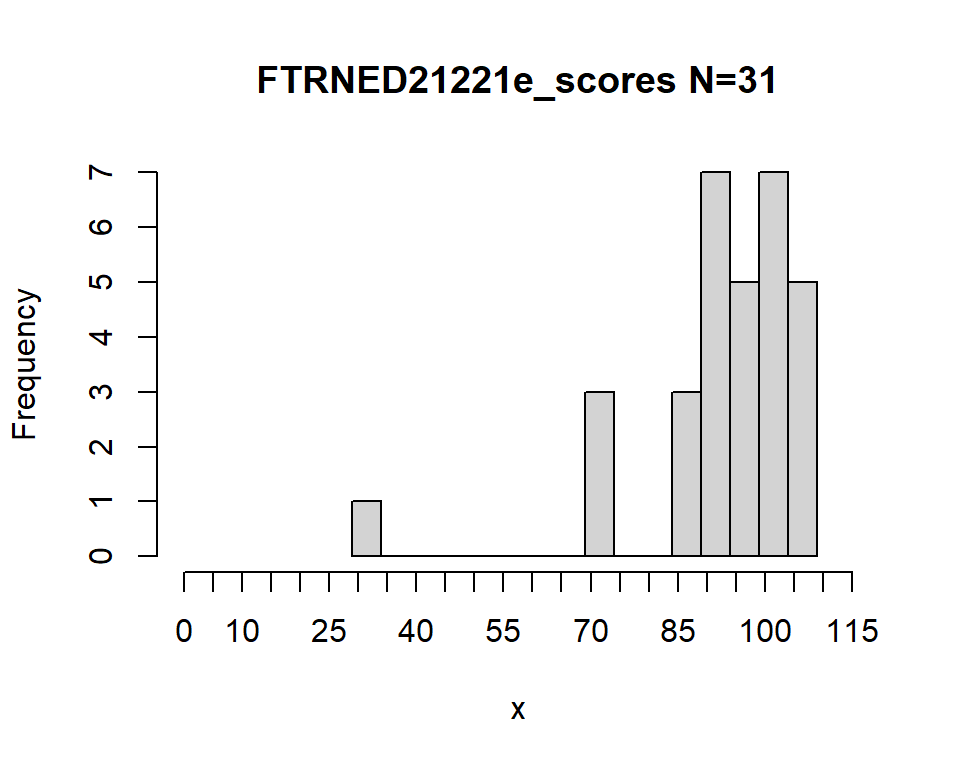

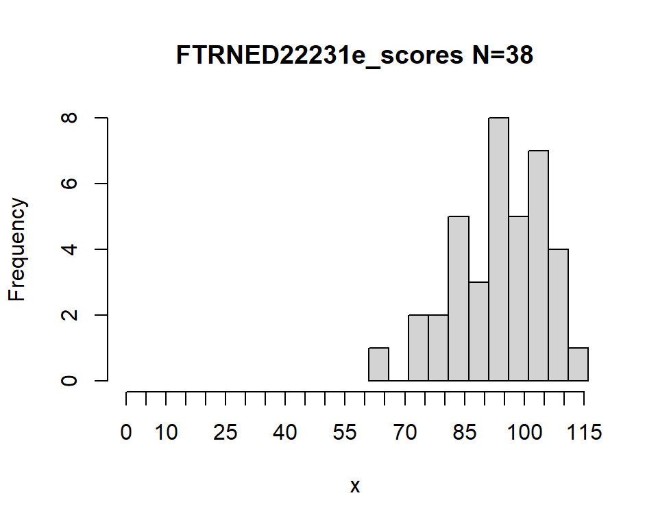

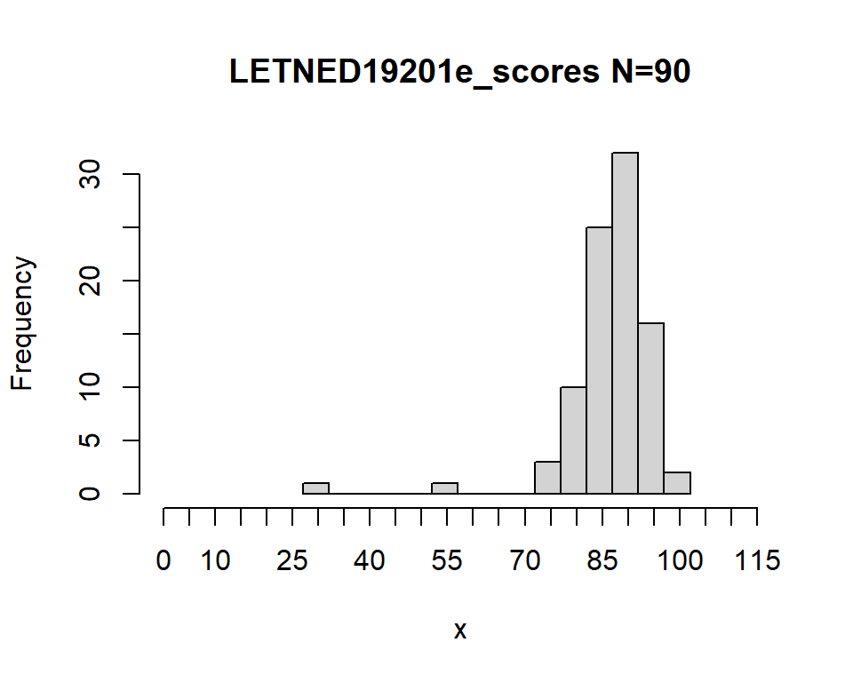

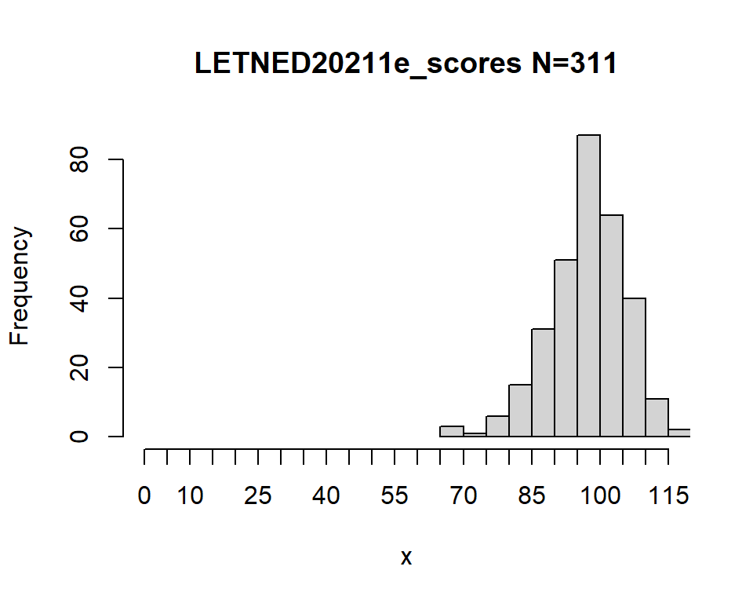

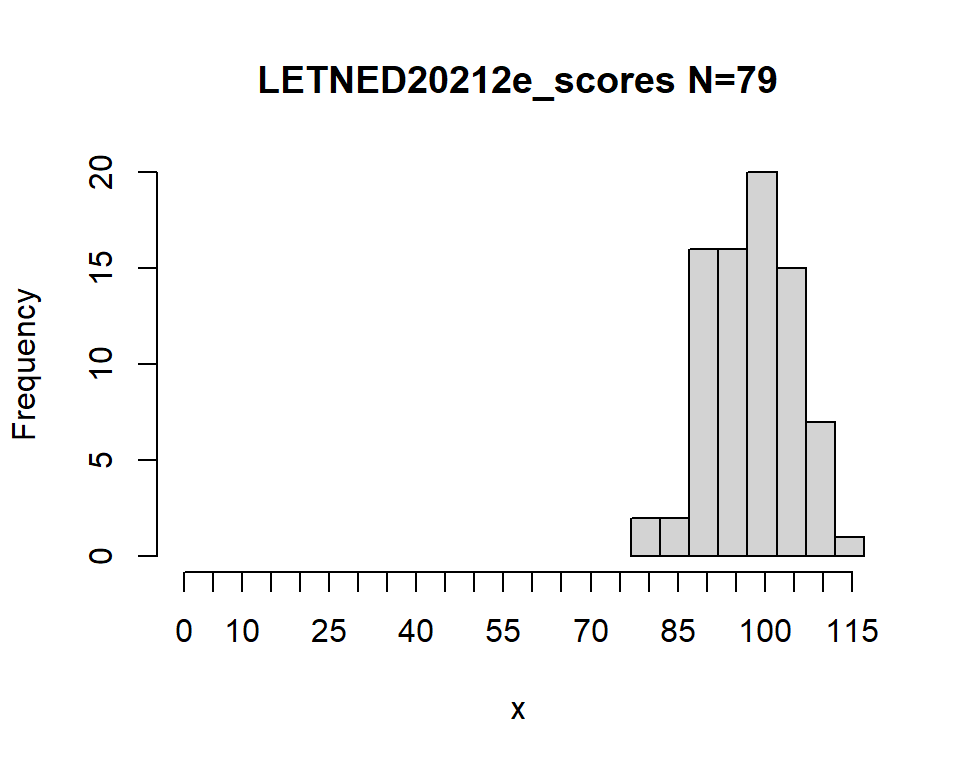

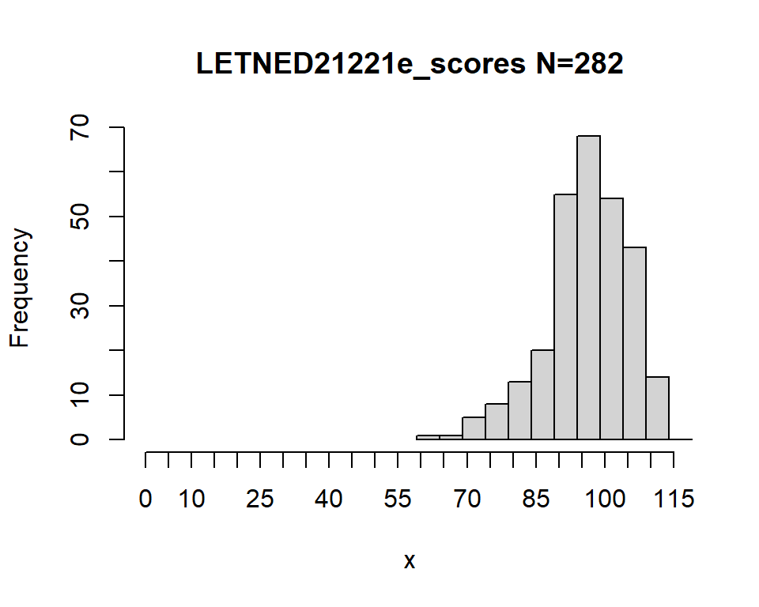

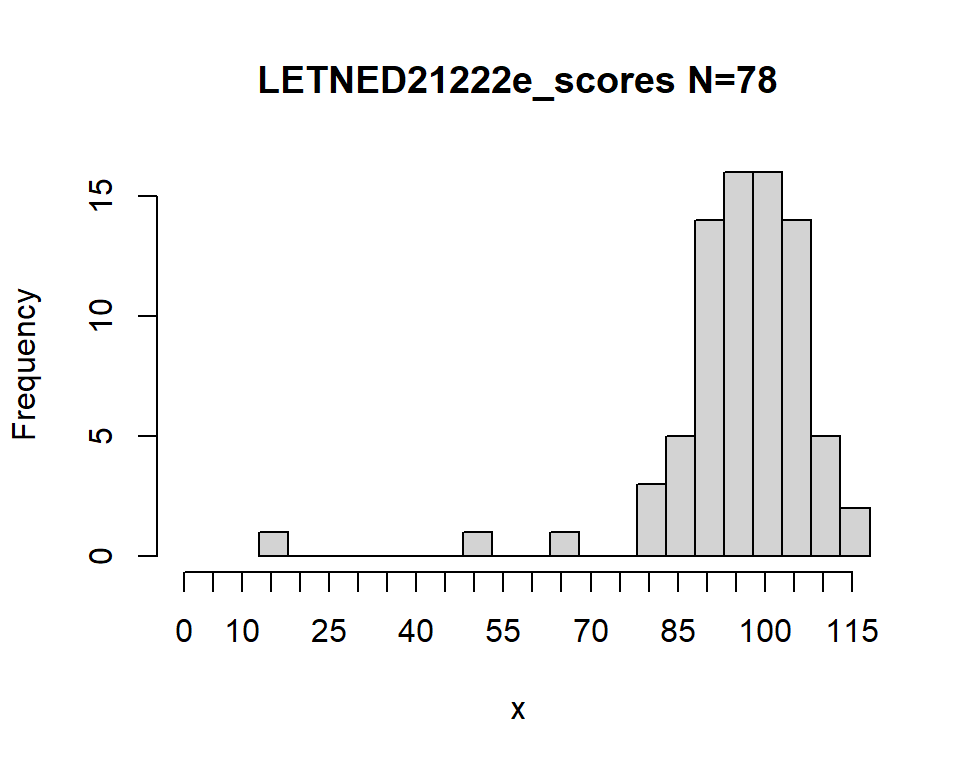

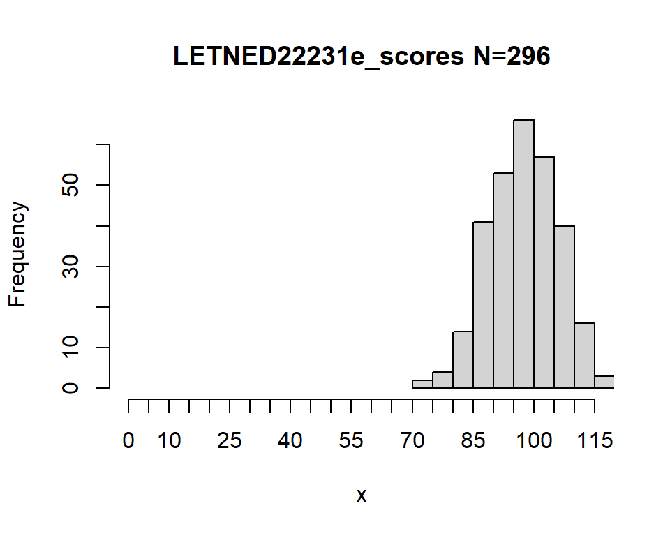

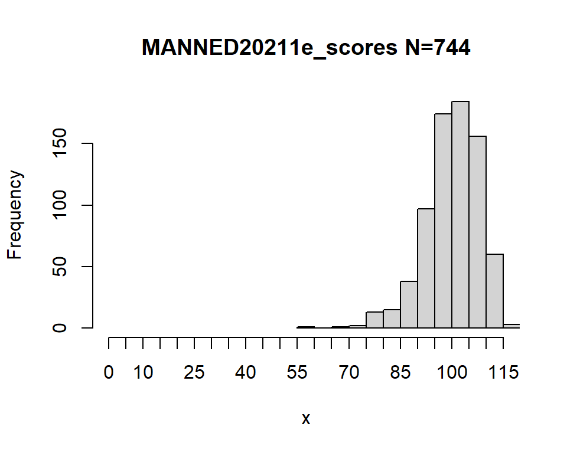

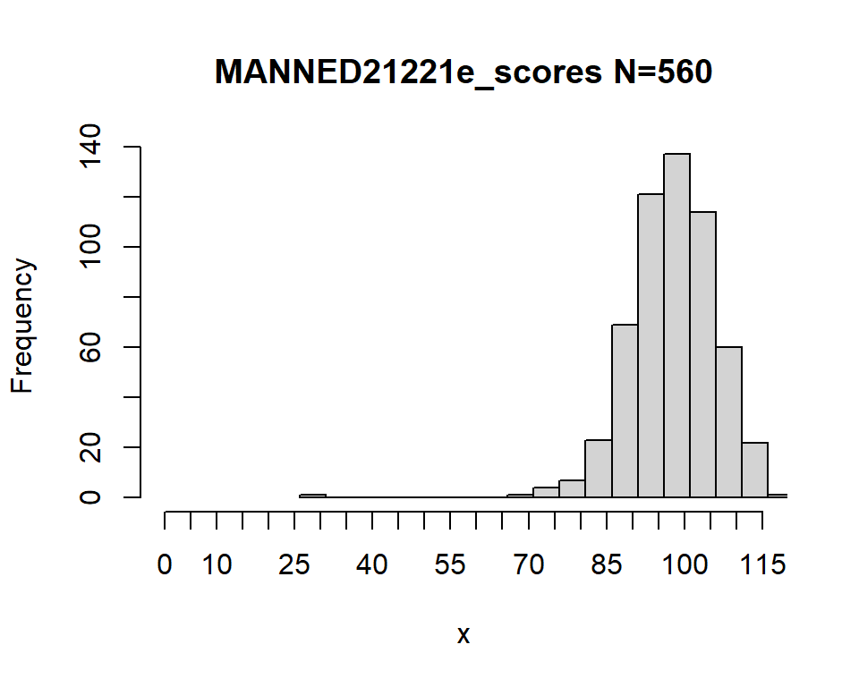

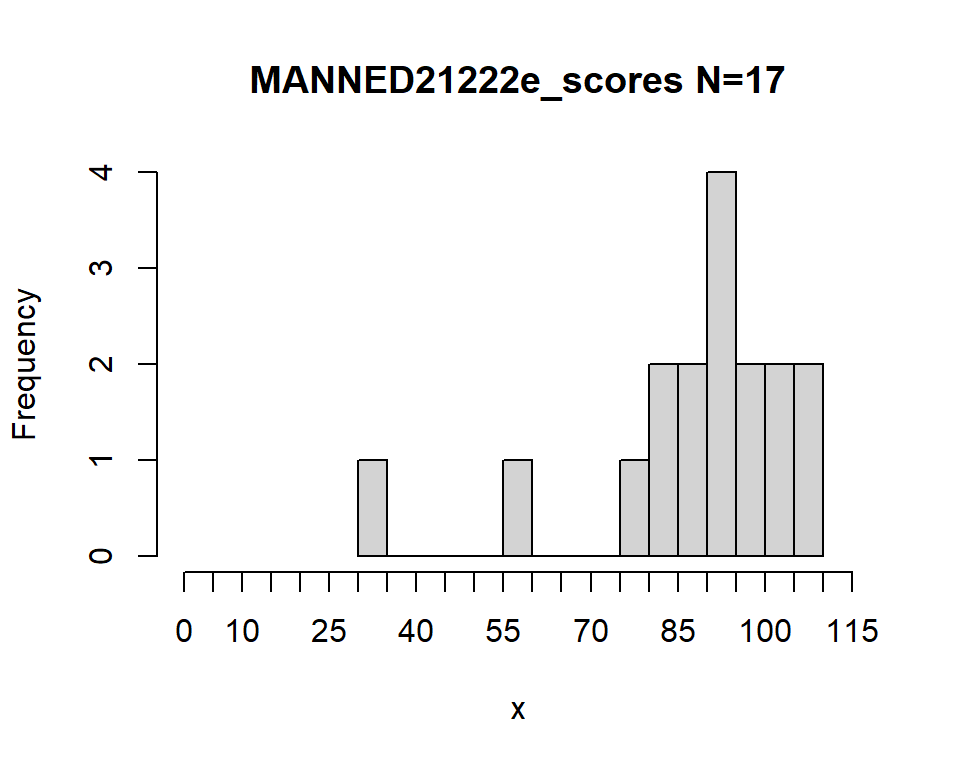

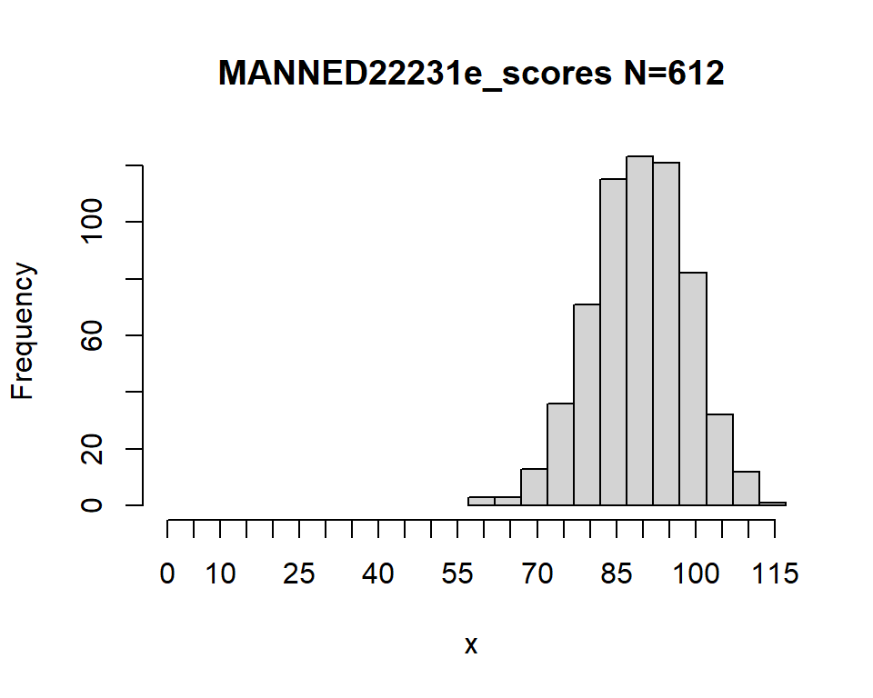

[5 more figures not shown]

```r
# Set the bin width you want (e.g., 5)
bin_width <- 5
x_axis_range <- c(0, 115)  # Set the desired x-axis range
x_axis_ticks <- seq(0, 115, by = 5)  # Generate ticks at intervals of 5

for (name in scores_admins) {
  x <- get(name)
  y <- length(x)
  hist(x, main = "", breaks = seq(min(x), max(x) + bin_width, by = bin_width), xlim = x_axis_range, xaxt = "n")
  title(paste0(name, " N=", y))
  axis(1, at = x_axis_ticks)
}
```

And the boxplots.

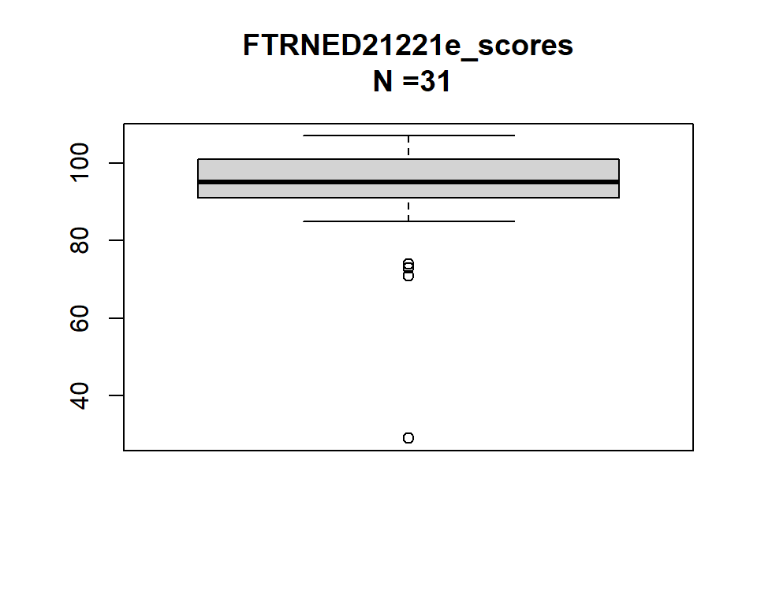

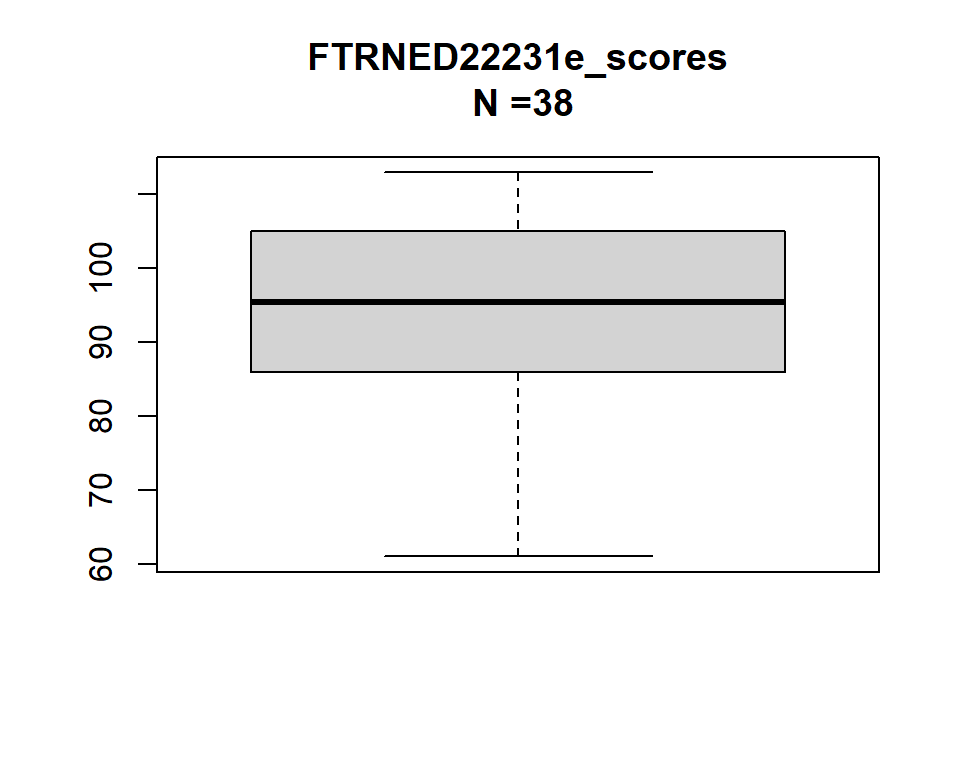

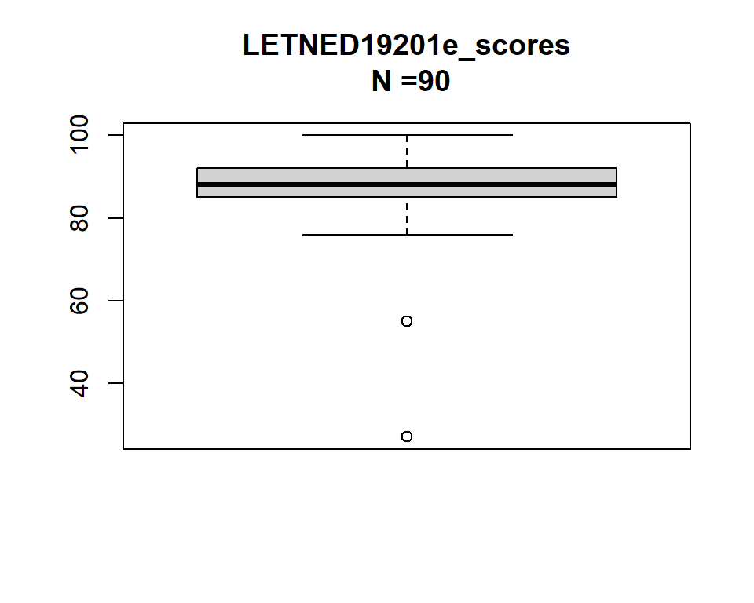

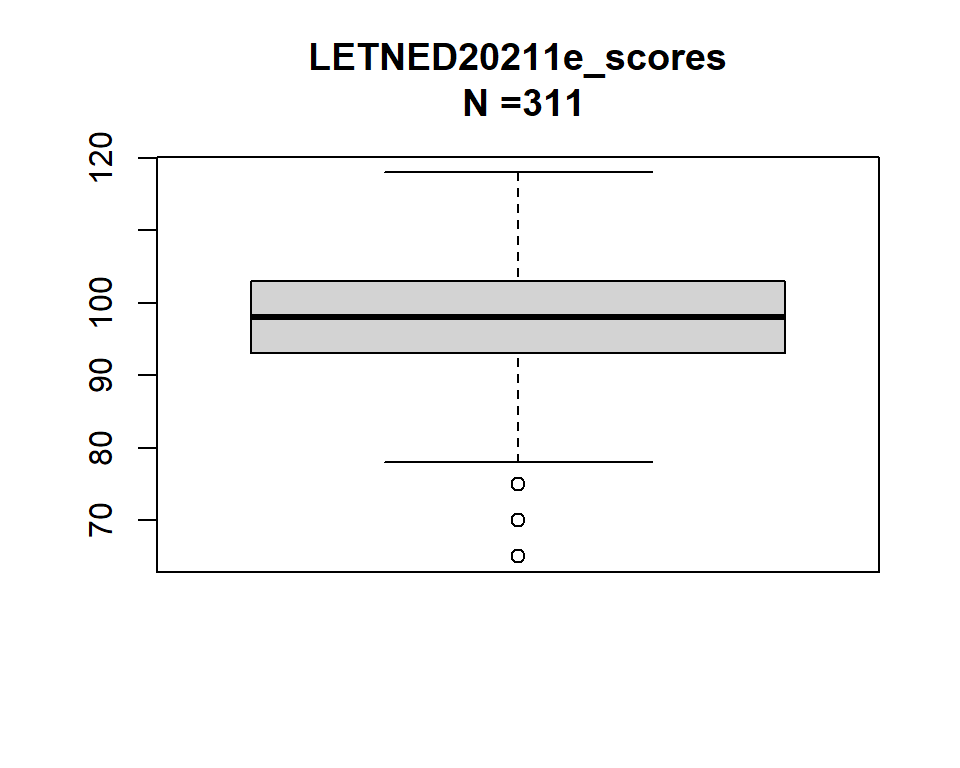

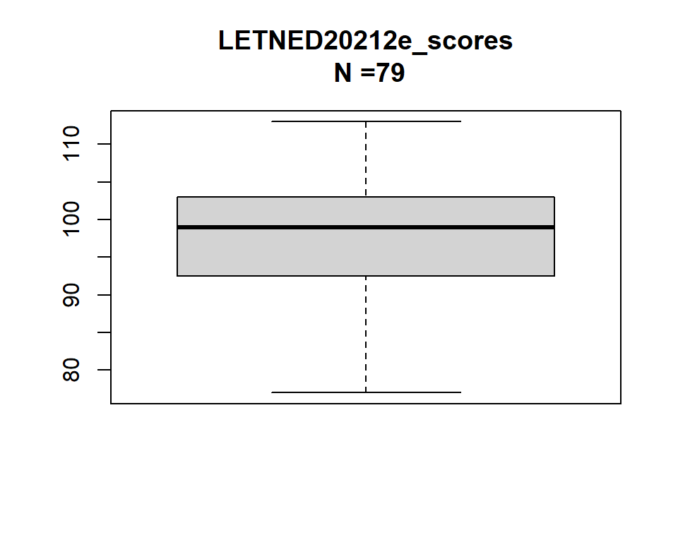

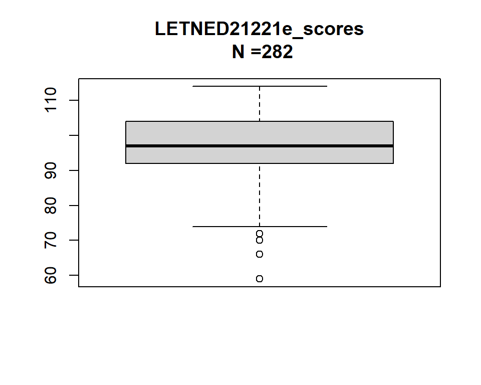

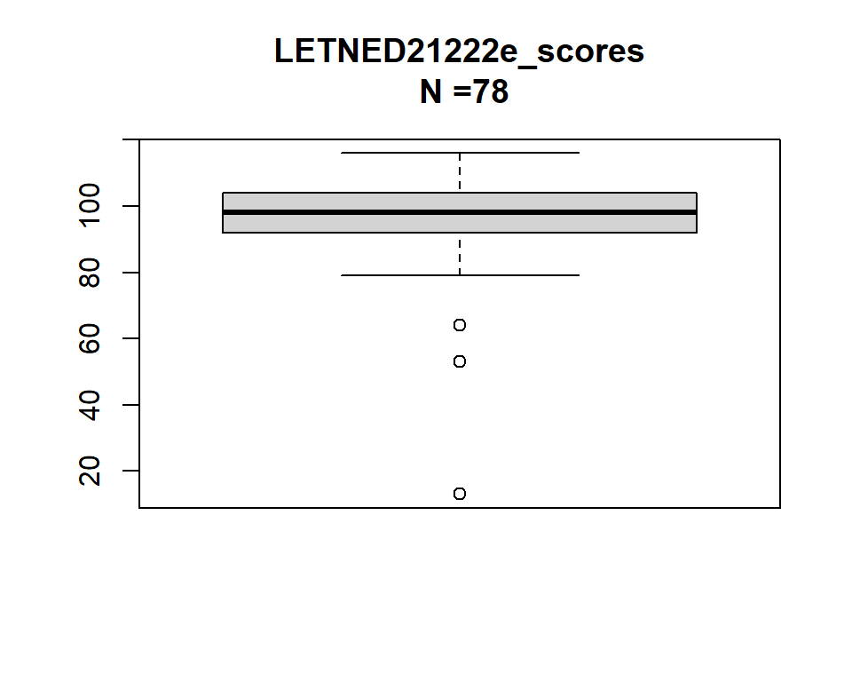

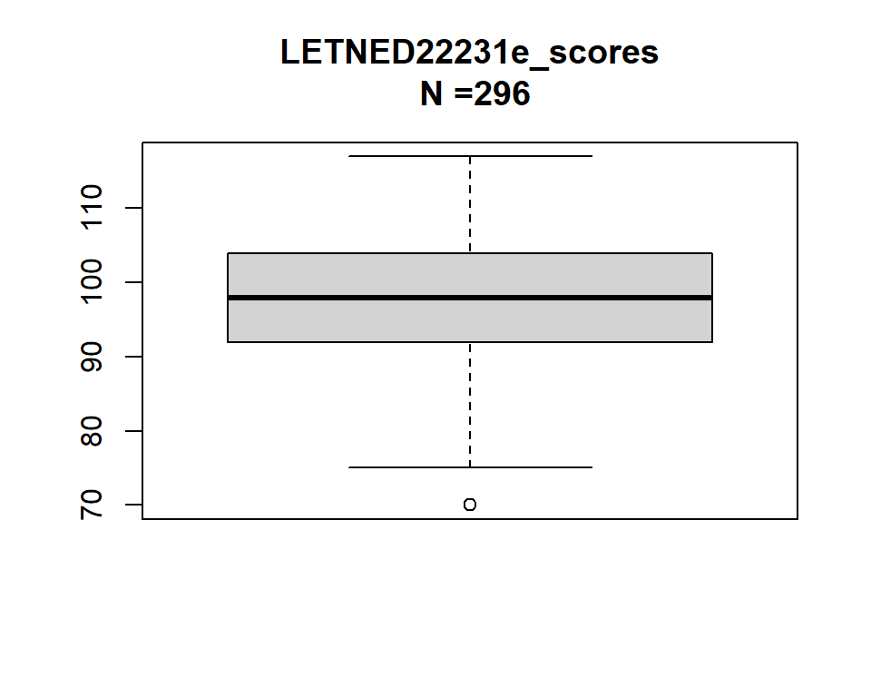

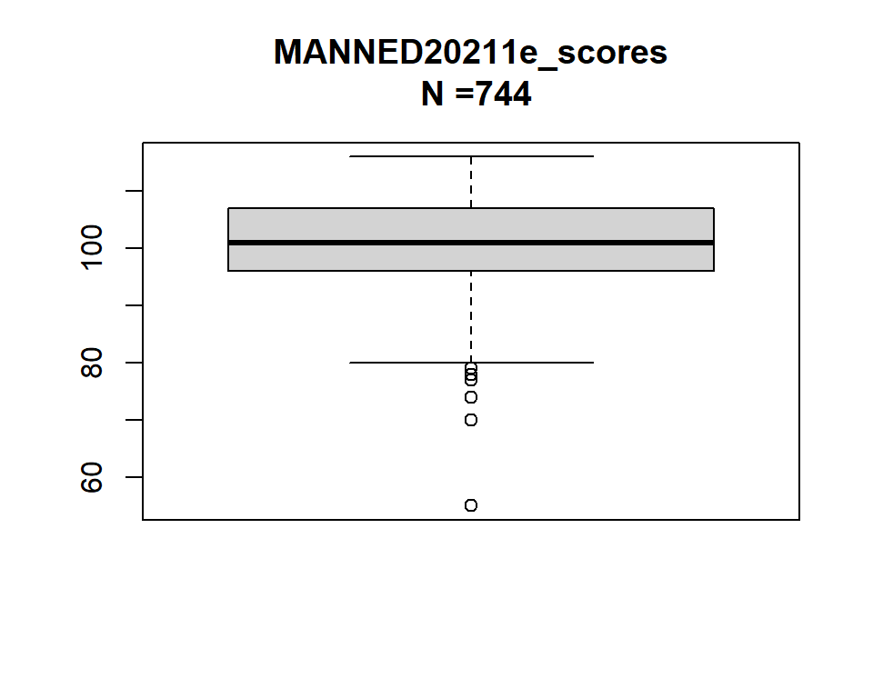

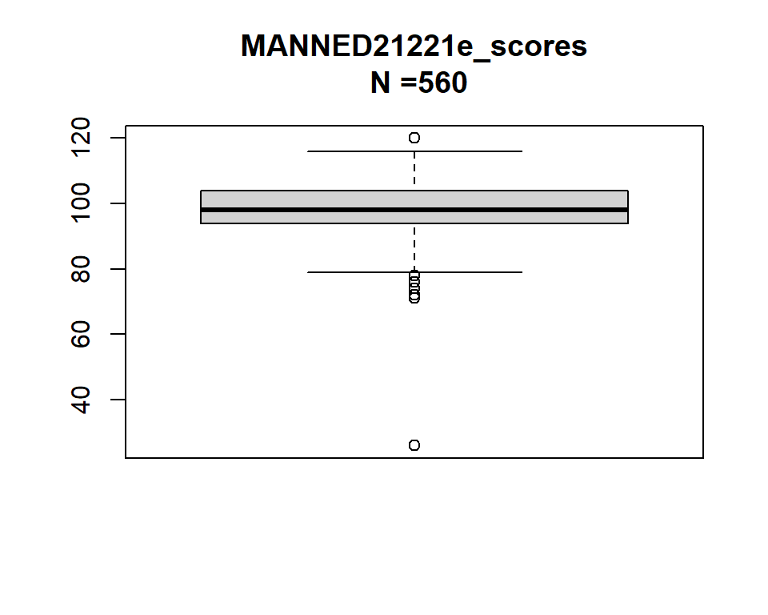

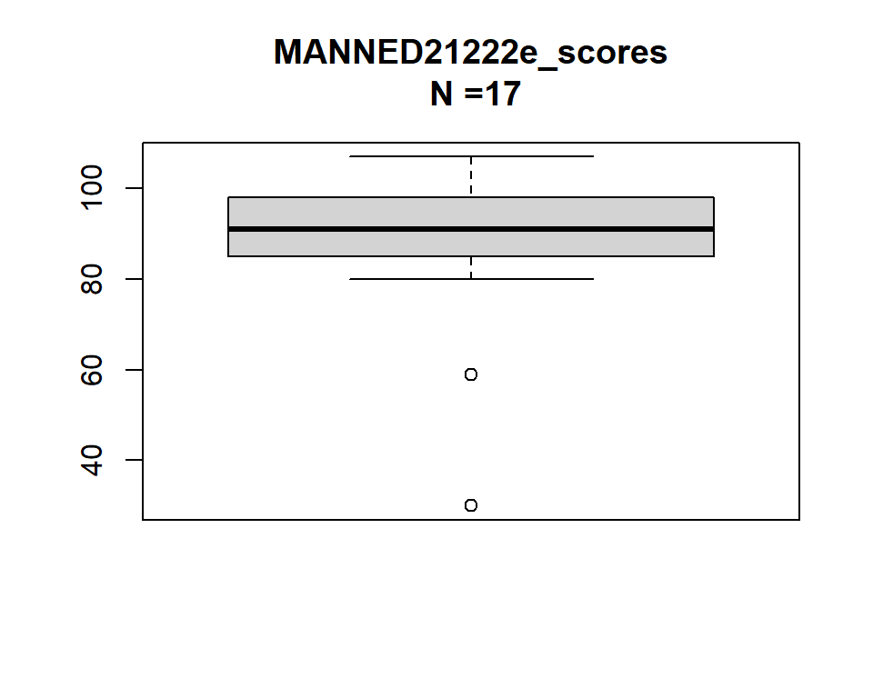

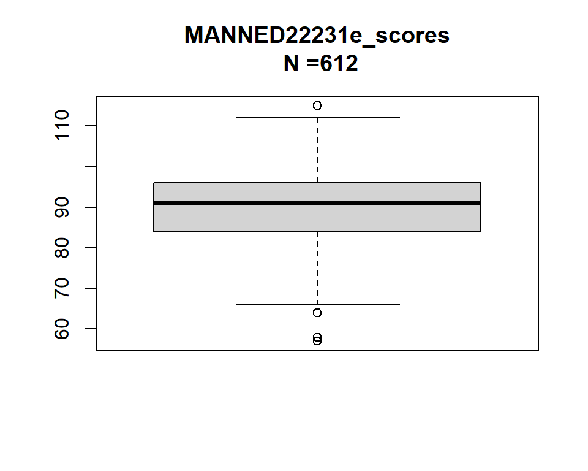

[5 more figures not shown]

```r
for (name in scores_admins) {
  x <- get(name)
  y <- length(x)
  boxplot(x, main = "", width = 3)
  title(paste0(name, "\n N =", y))
}
```

# 3 Outliers

The boxplots reveal a number of outliers at the lower end of the score range.

This test is required, but has no consequences. It is possible that some students did not seriously attempt the test, perhaps abandoning it halfway through or skipping sections. It is important to identify these and remove them so that all outlying scores are accurate representations of ability.

72 outliers are identified below, and are stored for future inspection.

```r
outliers_all <- c()
for (name in scores_admins) {
  x <-get(name)
  # Calculate the interquartile range (IQR)
  q1 <- quantile(x, 0.25)
  q3 <- quantile(x, 0.75)
  iqr <- q3 - q1

# Define the lower and upper bounds for outliers
  lower_bound <- q1 - 1.5 * iqr
  upper_bound <- q3 + 1.5 * iqr

# Identify outliers
  outliers <- x[x < lower_bound | x > upper_bound]
  outliers_all<- c(outliers_all, outliers)
# Print the outliers

}
sorted_outliers <- sort (outliers_all)
# Create histogram with bins of width 5
length(sorted_outliers)
```

```
## [1] 72
```

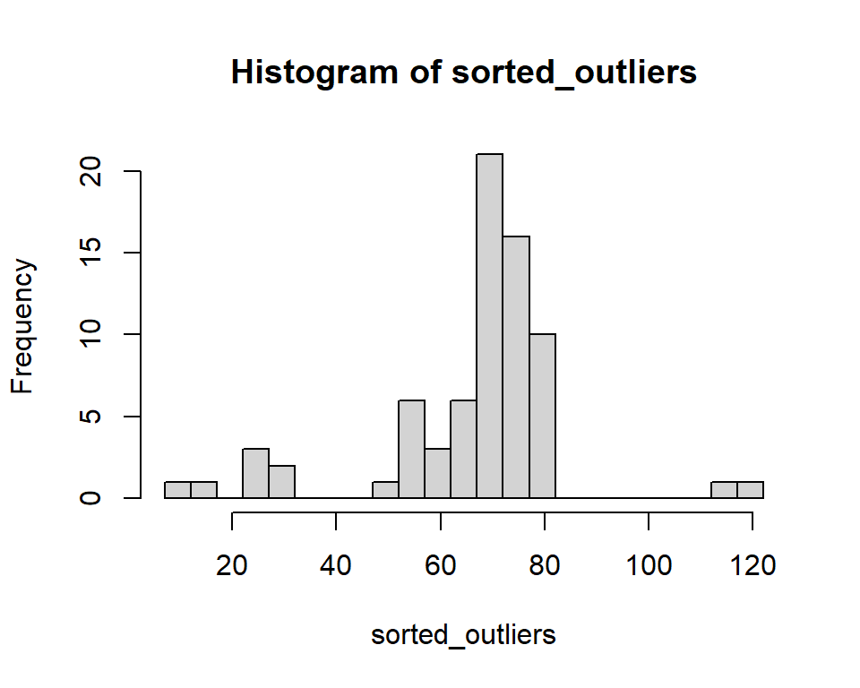

```r
hist(sorted_outliers, breaks = seq(min(sorted_outliers), max(sorted_outliers) + 5, by = 5))
```

# 4 Expand Dataset

We can now create nedallplus, a data frame which has additional information for each candidate in a number of new rows. New rows: ADMIN, NUMBER_ITEMS, FORM, MAX_SCORE, RAW_SCORE, PERCENT_SCORE

```r
column_names <- colnames(nedall)
ADMIN <- substr(column_names, 1, 12)
nedallplus1 <- rbind(ADMIN, nedall)
rownames(nedallplus1)[1] <- "ADMIN"
```

```r
ITEMS <- c()
admin_vector <- as.vector(nedallplus1["ADMIN", ])
for (i in 1:ncol(nedallplus1)) {
  admin_value <- admin_vector[i]
  match_row <- match(admin_value, mean_max_table$Admin)
  mean_max_value <- mean_max_table$Mean_Max[match_row]
  ITEMS <- c(ITEMS, mean_max_value)
}
nedallplus2 <- rbind(ITEMS,nedallplus1)
rownames(nedallplus2)[1] <- "NUMBER_ITEMS"
```

More information about FORM

```r
forms_to_admins_vector <- c("FTRNED21221e","FTRNED(A)",
                            "FTRNED22231e","FTRNED(A)",
                            "LETNED19201e","LETNED(A)",
                            "LETNED20211e","LETNED(B)",
                            "LETNED21221e", "LETNED(B)",
                            "LETNED22231e", "LETNED(B)",
                            "LETNED20212e", "LETNED(C)",
                            "LETNED21222e", "LETNED(C)",
                            "MANNED20211e", "MANNED(A)",
                            "MANNED21221e", "MANNED(A)",
                            "MANNED21222e", "MANNED(A)",
                            "MANNED22231e", "MANNED(B)",
                            "MEDNED21221e", "MEDNED(A)",
                            "MEDNED22231e", "MEDNED(A)",
                            "NWINED21221e", "NWINED(A)",
                            "NWINED22231e", "NWINED(A)",
                            "SOWNED22231e", "SOWNED(A)")
forms_admins_matrix <- matrix(forms_to_admins_vector,ncol=2,byrow=TRUE)
forms_admins_matrix <- as.data.frame(forms_admins_matrix)
names<- c("ADMIN", "FORM")
rownames(forms_admins_matrix) <- NULL
colnames(forms_admins_matrix) <- names
print(forms_admins_matrix)
```

```
##           ADMIN      FORM
## 1  FTRNED21221e FTRNED(A)
## 2  FTRNED22231e FTRNED(A)
## 3  LETNED19201e LETNED(A)
## 4  LETNED20211e LETNED(B)
## 5  LETNED21221e LETNED(B)
## 6  LETNED22231e LETNED(B)
## 7  LETNED20212e LETNED(C)
## 8  LETNED21222e LETNED(C)
## 9  MANNED20211e MANNED(A)
## 10 MANNED21221e MANNED(A)
## 11 MANNED21222e MANNED(A)
## 12 MANNED22231e MANNED(B)
## 13 MEDNED21221e MEDNED(A)
## 14 MEDNED22231e MEDNED(A)
## 15 NWINED21221e NWINED(A)
## 16 NWINED22231e NWINED(A)
## 17 SOWNED22231e SOWNED(A)
```

```r
FORM <- c()
admin_vector <- as.vector(nedallplus2["ADMIN", ])
for (i in 1:ncol(nedallplus2)) {
  admin_value <- admin_vector[i]
  match_row <- match(admin_value, forms_admins_matrix[,1])
  form_value <- forms_admins_matrix[,2][match_row]
  FORM <- c(FORM, form_value)
}
nedallplus3 <- rbind(FORM, nedallplus2)
rownames(nedallplus3)[1]<- "FORM"
```

The hotspot items are the only non-dichotomous items. Therefore the NUMBER_ITEMS row does not actually give us the maximum score for each form/admin. Cross-referencing all NED hotspot items in use in Cirrus confirms that all have a max of 7. in’to Languages has a way to adjust this to a max of 8, so scores in the data have a max of 8. However, one form - LETNED(A) - does not have a hotspot at all, so the NUMBER_ITEMS is actually the max.

The vector hotspot_max contains the max hotspot scores for all administrations. This is used to create MAX_SCORE.

```r
hotspot_max <- c(8,8,0,8,8,8,8,8,8,8,8,8,8,8,8,8,8)
forms_admins_hotspots_matrix <- cbind(forms_admins_matrix, hotspot_max)
```

```r
hotspot_max <- c()
admin_vector <- as.vector(nedallplus2["ADMIN", ])
for (i in 1:ncol(nedallplus3)) {
  admin_value <- admin_vector[i]
  match_row <- match(admin_value, forms_admins_hotspots_matrix[,1])
  form_value <- forms_admins_hotspots_matrix[,3][match_row]
  hotspot_max <- c(hotspot_max, form_value)
}

nedallplus4 <- rbind(hotspot_max, nedallplus3)
rownames(nedallplus4)[1]<- "HSPOT_MAX"
# calculate row MAX_SCORE
x <- as.vector(as.numeric(nedallplus4["HSPOT_MAX",]))
y <- as.vector(as.numeric(nedallplus4["NUMBER_ITEMS",]))
z <- c(x+y)
nedallplus5 <- rbind(z, nedallplus4)
rownames(nedallplus5)[1]<- "MAX_SCORE"
```

```r
col_sum <- c()
for (i in 1:ncol(nedallplus5)) {
  x <- nedallplus5[6:nrow(nedallplus5),i]
  y <- as.numeric(x)
  z <- sum(y, na.rm=TRUE)
  col_sum <- c(col_sum, z)
}
nedallplus6 <- rbind(col_sum, nedallplus5)
rownames(nedallplus6)[1]<- "RAW_SCORE"
```

```r
x <- as.vector(as.numeric(nedallplus6["MAX_SCORE",]))
y <- as.vector(as.numeric(nedallplus6["RAW_SCORE",]))
z <- c(y/x)
nedallplus7 <- rbind(z, nedallplus6)
rownames(nedallplus7)[1]<- "PERCENT_SCORE"
```

The new dataset is data frame nedallplus

```r
nedallplus <- nedallplus7
```

# 5 Descriptives / Form

A summary of all forms:

```r
forms <- unlist(as.vector(nedallplus["FORM", ]))
scores <- as.numeric(unlist(as.vector(nedallplus["PERCENT_SCORE",])))
forms_scores <- data.frame(FORM=forms,SCORES=scores)

summary <- forms_scores %>%
  group_by(FORM) %>%
  summarise(
    count = n(),
    min_score = round(min(SCORES), 2),
    max_score = round(max(SCORES), 2),
    mean_score = round(mean(SCORES), 2),
    sd_score = round(sd(SCORES), 2)
  )

# Print the result
print(summary)
```

```
## # A tibble: 9 × 6
##   FORM      count min_score max_score mean_score sd_score
##   <chr>     <int>     <dbl>     <dbl>      <dbl>    <dbl>
## 1 FTRNED(A)    69      0.24      0.92       0.76     0.11
## 2 LETNED(A)    90      0.24      0.88       0.77     0.08
## 3 LETNED(B)   889      0.48      0.96       0.79     0.07
## 4 LETNED(C)   157      0.11      0.94       0.79     0.09
## 5 MANNED(A)  1321      0.21      0.98       0.81     0.07
## 6 MANNED(B)   612      0.46      0.93       0.73     0.07
## 7 MEDNED(A)   932      0.41      0.93       0.77     0.07
## 8 NWINED(A)   117      0.43      0.93       0.77     0.08
## 9 SOWNED(A)   794      0.06      0.93       0.76     0.07
```

The violin charts below show the distribution of scores per form.

The red line is the average for the overall test and the black dots show the form means.

```r
# Calculate means by form
overall_mean<- forms_scores %>%
  summarize(mean_score = mean(SCORES))

overall_mean <-unlist(overall_mean)
cat("overall average:", overall_mean)
```

```
## overall average: 0.7781103
```

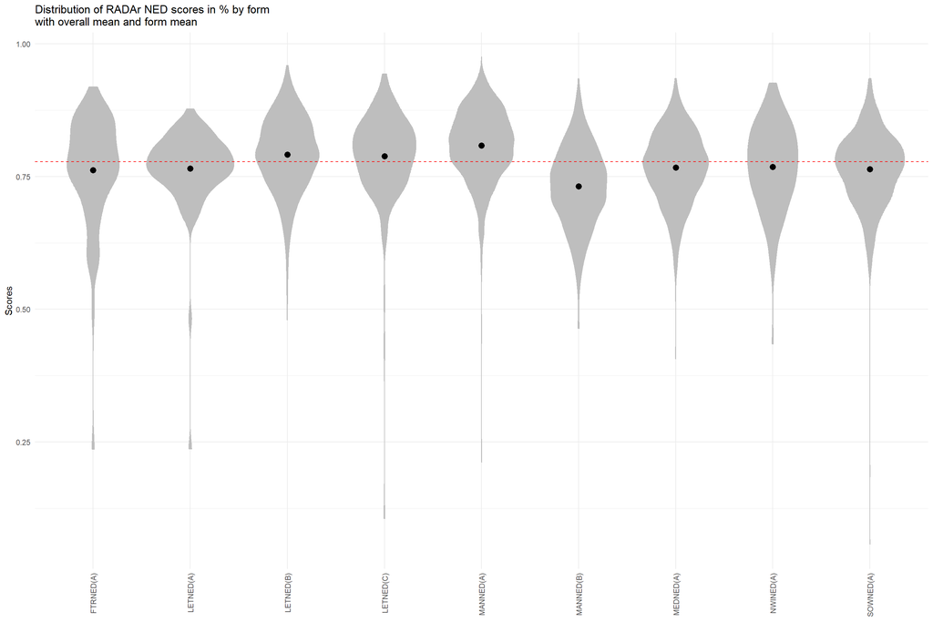

```r
mean_scores <- forms_scores %>%
  group_by(FORM) %>%
  summarise(mean_score = mean(SCORES))

# Create the violin plot
ggplot(forms_scores, aes(x = FORM, y = SCORES)) +
  geom_violin(fill = "gray", color = "gray") +
  geom_hline(aes(yintercept = mean(SCORES)), linetype = "dashed", color = "red") +
  geom_point(data = mean_scores, aes(x = FORM, y = mean_score), color = "black", size = 3, shape = 19) +
  labs(title = "Distribution of RADAr NED scores in % by form\nwith overall mean and form mean") +
  xlab(NULL) +
  ylab("Scores") +
  theme_minimal() +
  theme(axis.text.x = element_text(angle = 90, vjust = 0.5, hjust=1))
```

# 6 Remove outliers

The appearence of outliers is quite clear in the violin charts above, and are likely skewing figures. 72 outliers were identified earlier. Now, we will see which make sense to remove.

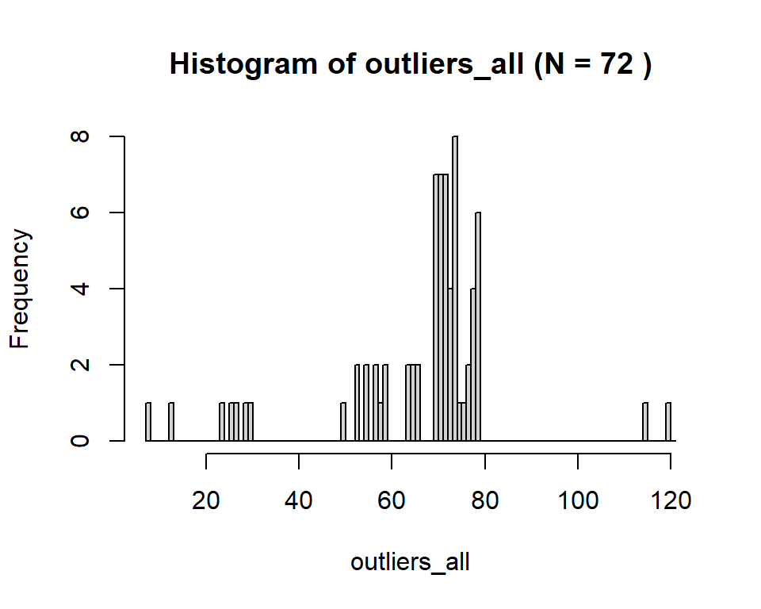

```r
hist(outliers_all,
     breaks = seq(min(sorted_outliers), max(sorted_outliers) + 1, by = 1),
     main = paste("Histogram of outliers_all (N =", length(outliers_all), ")"))
```

For this iteration, I saved this file with the date “outliers_excel_20230713”, and visually inspected the data

```r
nedallplus_t <- t(nedallplus)
names_outliers_all <- names(outliers_all)
outliers_df <- data.frame(testtaker=names_outliers_all, score=outliers_all)
outliers_details <- nedallplus_t[outliers_df$testtaker,]
# Collapse the data frame
outliers_details_collapsed <- as.data.frame(t(apply(outliers_details, 1, function(x) {
  x <- na.omit(x)
  c(x, rep(NA, ncol(outliers_details) - length(x)))
})))

#create excel sheet by running below code:
#write.csv(outliers_details_collapsed, "outliers_excel.csv")
```

Which should we exclude?

1. Abandonment, defined as all 0s in the last or last two sections.

FTRNED21221e8 FTRNED21221e29 LETNED21222e63 MANNED20211e680 MANNED21221e277 MANNED21222e16 MEDNED21221e71

2. Sections Skipped, defined as having sections of all 0s in an otherwise normal looking test response.

LETNED19201e3 LETNED19201e40 MANNED21222e3 MANNED22231e516 MANNED22231e70 MEDNED22231e412 NWINED21221e76 SOWNED22231e792 SOWNED22231e793

3. Other

Remaining outliers are arranged from lowest to highest score. No high scoring outliers are removed from the set. Response patterns of low scoring outliers who were not flagged in the previous two steps were inspected. Two further were flagged for removal:

MANNED22231e71 MANNED22231e262

The excel file outliers_excel_20230713.xlsx contains the data for this process, with the abandoned tests flagged in orange, the section abandonments flagged on yellow, and suspicious low scorers in blue. The list is preserved in outliers_excel_20230713_list.csv for access by r.

The new dataset is nedallplus_no_outliers.

# 7 Descriptives / Form (no outliers)

Now, let’s rerun our descriptive stats and violin charts, using the nedallplus_no_outliers data set.

```r
forms2 <- unlist(as.vector(nedallplus_no_outliers["FORM", ]))
scores2 <- as.numeric(unlist(as.vector(nedallplus_no_outliers["PERCENT_SCORE",])))
forms_scores2 <- data.frame(FORM=forms2, SCORES=scores2)

summary <- forms_scores2 %>%
  group_by(FORM) %>%
  summarise(
    count = n(),
    min_score = round(min(SCORES),2),
    max_score = round(max(SCORES),2),
    mean_score = round(mean(SCORES),2),
    sd_score = round(sd(SCORES),2)
  )

# Print the result
print(summary)
```

[output not shown]

The min scores show the influence of having the outliers removed. The adjusted overall average and violin chart is below.

```r
# Calculate means by form
overall_mean2<- forms_scores2%>%
  summarize(mean_score = mean(SCORES))

overall_mean2 <-unlist(overall_mean2)
cat("overall average:", overall_mean2)
```

```
## overall average: 0.7796595
```

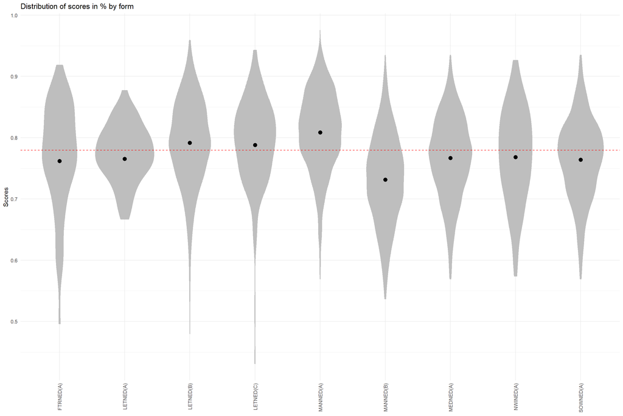

```r
mean_scores2 <- forms_scores2 %>%
  group_by(FORM) %>%
  summarise(mean_score = mean(SCORES))

# Create the violin plot
ggplot(forms_scores2, aes(x = FORM, y = SCORES)) +
  geom_violin(fill = "gray", color = "gray") +
  geom_hline(aes(yintercept = mean(SCORES)), linetype = "dashed", color = "red") +
  geom_point(data = mean_scores, aes(x = FORM, y = mean_score), color = "black", size = 3, shape = 19) +
  labs(title = "Distribution of scores in % by form") +
  xlab(NULL) +
  ylab("Scores") +
  theme_minimal() +
  theme(axis.text.x = element_text(angle = 90, vjust = 0.5, hjust=1))
```

# 8 Differences in Mean: Form

Are any of these differences significant? An ANOVA will help us answer this. ## ANOVA assumptions There are assumptions about the data that must be checked before the ANOVA is performed. Independence: The data is independent. Normality: There is some question about the normality of the distributions of scores as the tend to be left skewed due to a ceiling effect. Homogeneity of Variance: This will need to be checked as well. Random Sampling: In this case, the sample is the population, so this assumption is met. ANOVAs are robust against non-normal distribution but we can still check. Kolmogorov–Smirnov is used for larger sample sizes (rather than Shapiro Wilk), but cannot handle data with tied values (which this data has).

Can we assume normality? perhaps we can inspect skew and kurtosis. If the skewness is negative, this indicates that the distribution is left-skewed. If the kurtosis is greater than 3, this indicates that the distribution has more values in the tails compared to a normal distribution (is flatter).

The table below shows all forms, with N, skew and kurtosis and mean(red) / median(blue) lines. Each form’s histogram is shown for reference. While one form has a high kurtosis, there do not appear to be any curves which vary too far from normal distribution…?

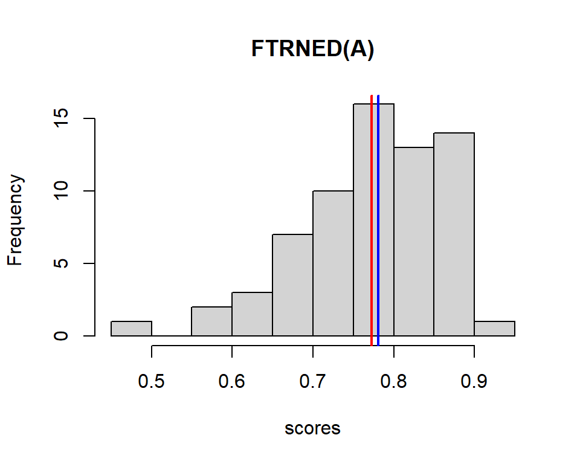

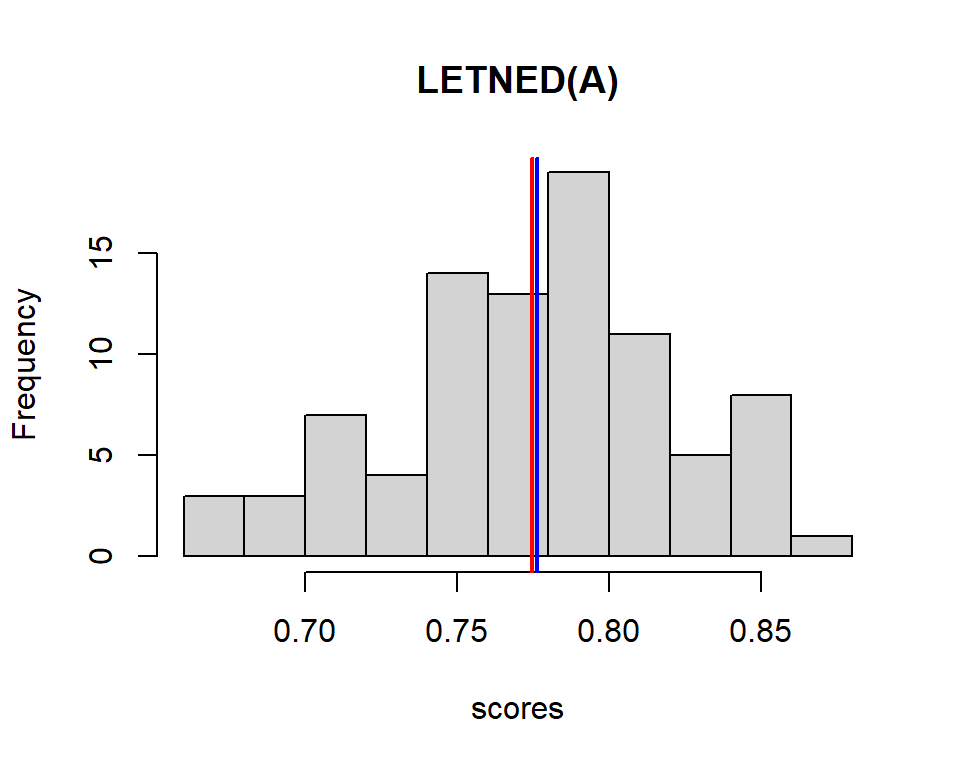

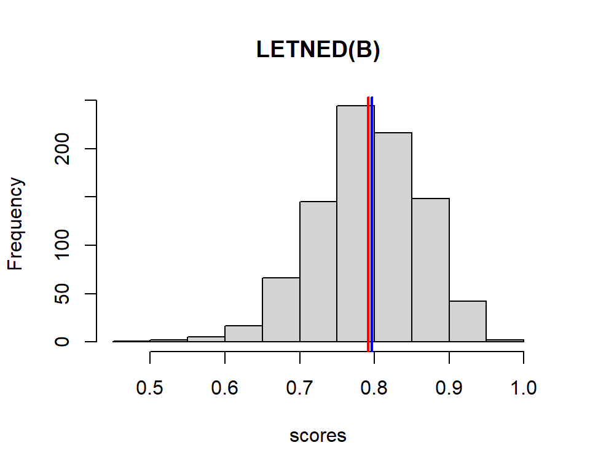

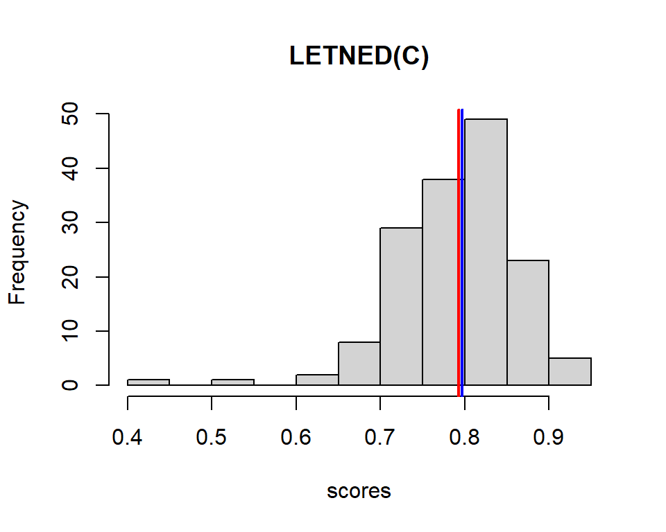

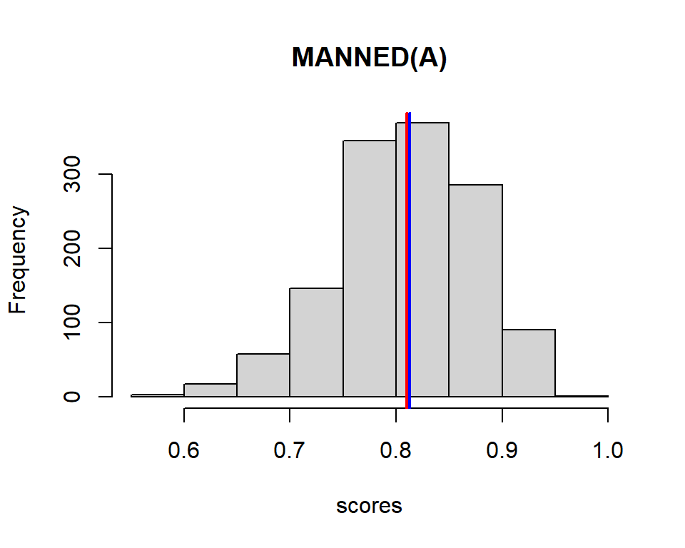

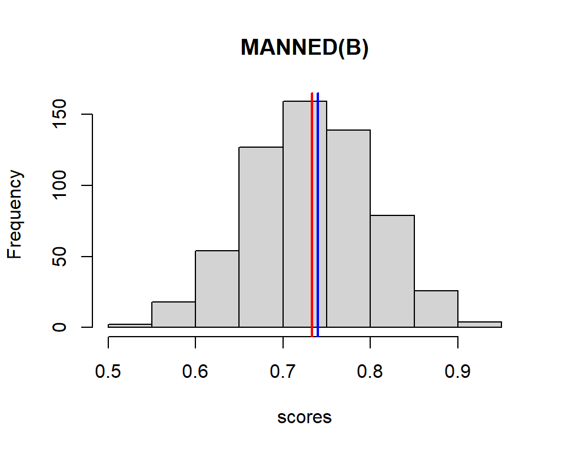

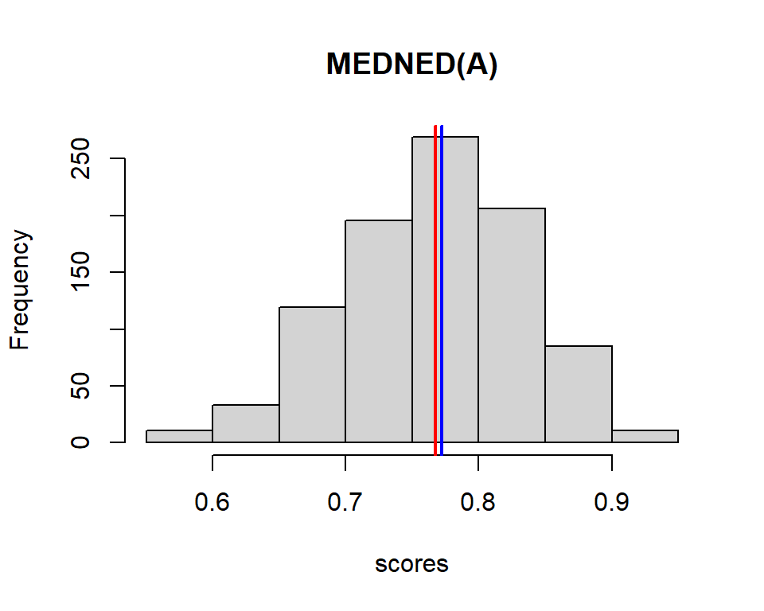

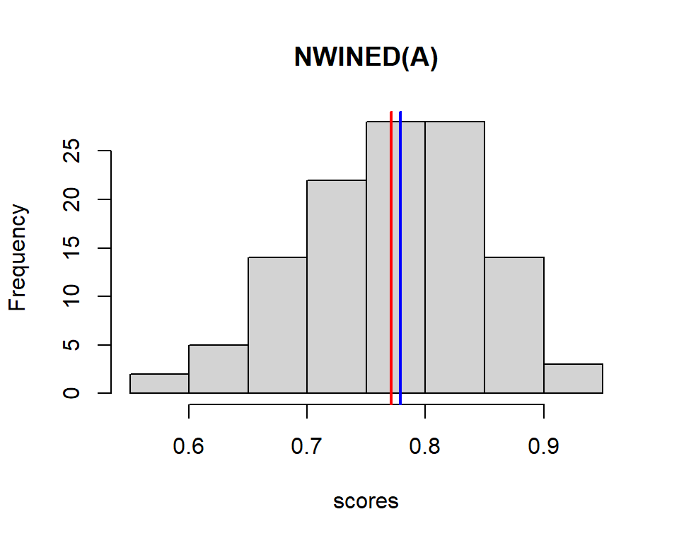

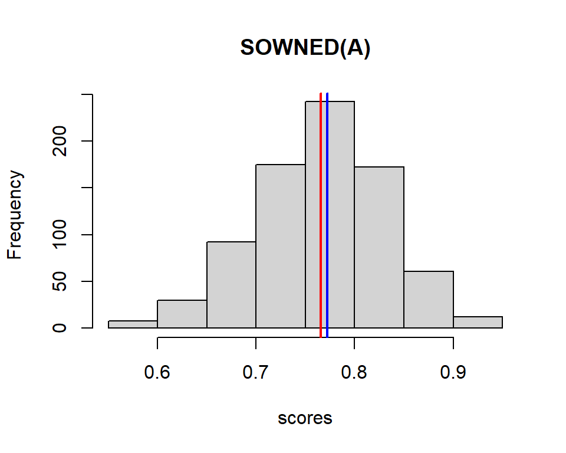

```r
library(moments)
results<- c()
for (group in unique(forms_scores2$FORM)) {
  scores <- forms_scores2$SCORES[forms_scores2$FORM == group]  # Subset scores for the current group
  skew <- skewness(scores)
  kurt <- kurtosis(scores)
  results<- c(results, group, length(scores), skew, kurt)
  hist(scores, main = group)
  # Calculate the mean and median
  mean_score <- mean(scores)
  median_score <- median(scores)

  # Add the mean line
  abline(v = mean_score, col = "red", lwd = 2)

  # Add the median line
  abline(v = median_score, col = "blue", lwd = 2)
}
```

```r
results_table <- matrix(results, ncol=4, byrow=TRUE)
colnames(results_table) <- c("Form", "N", "Skewness", "Kurtosis")
results_table
```

```
##       Form        N      Skewness              Kurtosis
##  [1,] "FTRNED(A)" "67"   "-0.866746461427531"  "3.68262469970813"
##  [2,] "LETNED(A)" "88"   "-0.22071767826167"   "2.64185551333682"
##  [3,] "LETNED(B)" "888"  "-0.507256000265831"  "3.60231823311163"
##  [4,] "LETNED(C)" "156"  "-1.19223291259285"   "7.20940213282873"
##  [5,] "MANNED(A)" "1317" "-0.466758163700513"  "3.23564212448772"
##  [6,] "MANNED(B)" "608"  "-0.0932021405321224" "2.72717772140685"
##  [7,] "MEDNED(A)" "930"  "-0.321312038230103"  "2.86398176543548"
##  [8,] "NWINED(A)" "116"  "-0.287190368804074"  "2.62005319444424"
##  [9,] "SOWNED(A)" "792"  "-0.28741958090608"   "3.05205983613512"
```

Based on these charts, and the robustness of ANOVA against non-normality, I believe this is OK. As for the assumption Homogeneity of Variance, inspection of boxplots will confirm or not.

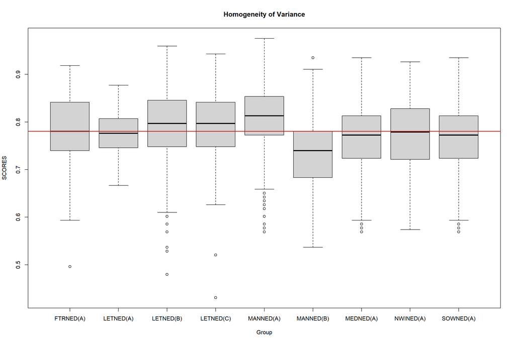

```r
# Create side-by-side boxplots
boxplot(SCORES ~ FORM, data = forms_scores2,
        main = "Homogeneity of Variance",
        xlab = "Group", ylab = "SCORES")

# Add a reference line at the overall median
overall_median <- median(forms_scores2$SCORES)
abline(h = overall_median, col = "red", lwd = 2)
```

However, we can test with Levene’s test:

```r
leveneTest(SCORES ~ FORM, data = forms_scores2)
```

```
## Levene's Test for Homogeneity of Variance (center = median)
##         Df F value    Pr(>F)
## group    8   4.819 6.279e-06 ***
##       4953
## ---
## Signif. codes:  0 '***' 0.001 '**' 0.01 '*' 0.05 '.' 0.1 ' ' 1
```

The p-value is very small (6.279e-06), indicating strong evidence against the null hypothesis. Therefore, we can conclude that there is evidence of heterogeneity of variances among the groups based on Levene’s test.

Let’s investigate now the magnitude of Heterogeneity: The larger the differences in variances among groups, the more serious the violation of the assumption. Large differences in variances can affect the precision of the estimated group means and can lead to biased estimates of the treatment effects.

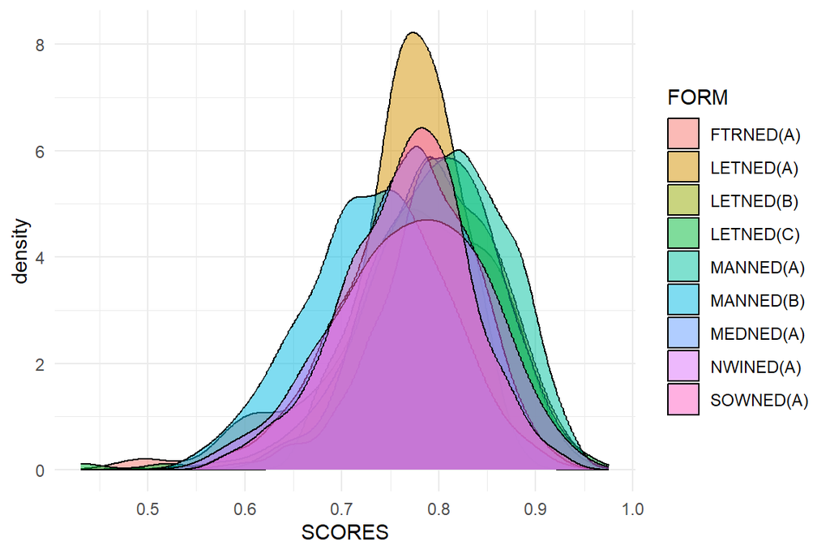

```r
group_variances <- tapply(forms_scores2$SCORES, forms_scores2$FORM, var)
group_sd <- tapply(forms_scores2$SCORES, forms_scores2$FORM, sd)

# Density plot
library(ggplot2)
ggplot(forms_scores2, aes(x = SCORES, fill = FORM)) +
  geom_density(alpha = 0.5) +
  theme_minimal()
```

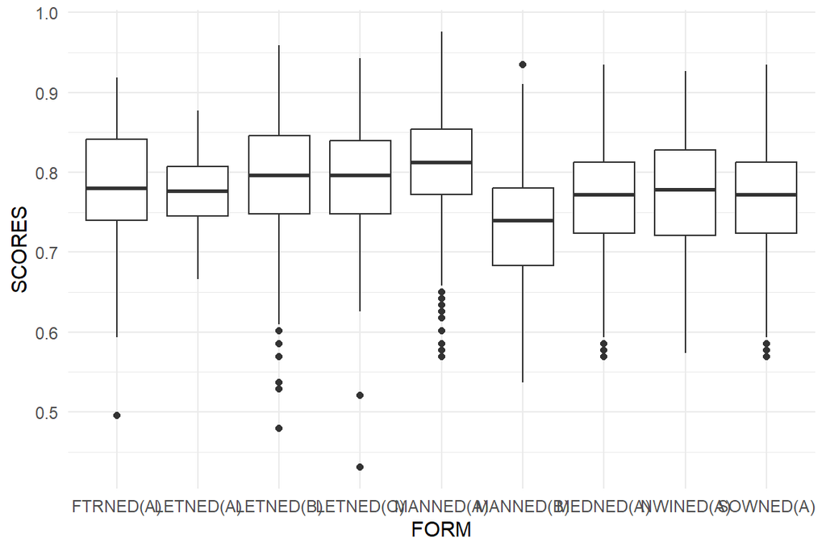

```r
# Boxplot
ggplot(forms_scores2, aes(x = FORM, y = SCORES)) +
  geom_boxplot() +
  theme_minimal()
```

```r
anova_result <- aov(SCORES ~ FORM, data = forms_scores2)
summary(anova_result)
```

```
##               Df Sum Sq Mean Sq F value Pr(>F)
## FORM           8  2.978  0.3723   81.96 <2e-16 ***
## Residuals   4953 22.499  0.0045
## ---
## Signif. codes:  0 '***' 0.001 '**' 0.01 '*' 0.05 '.' 0.1 ' ' 1
```

The p-value is extremely small (<2e-16), indicating strong evidence against the null hypothesis. Therefore, you can conclude that there are significant differences among the groups based on the ANOVA results.

Now, let’s do some post-hoc tests to see where these differences are.

```r
posthoc_tukey <- TukeyHSD(anova_result)
```

Let’s inspect this graphically:

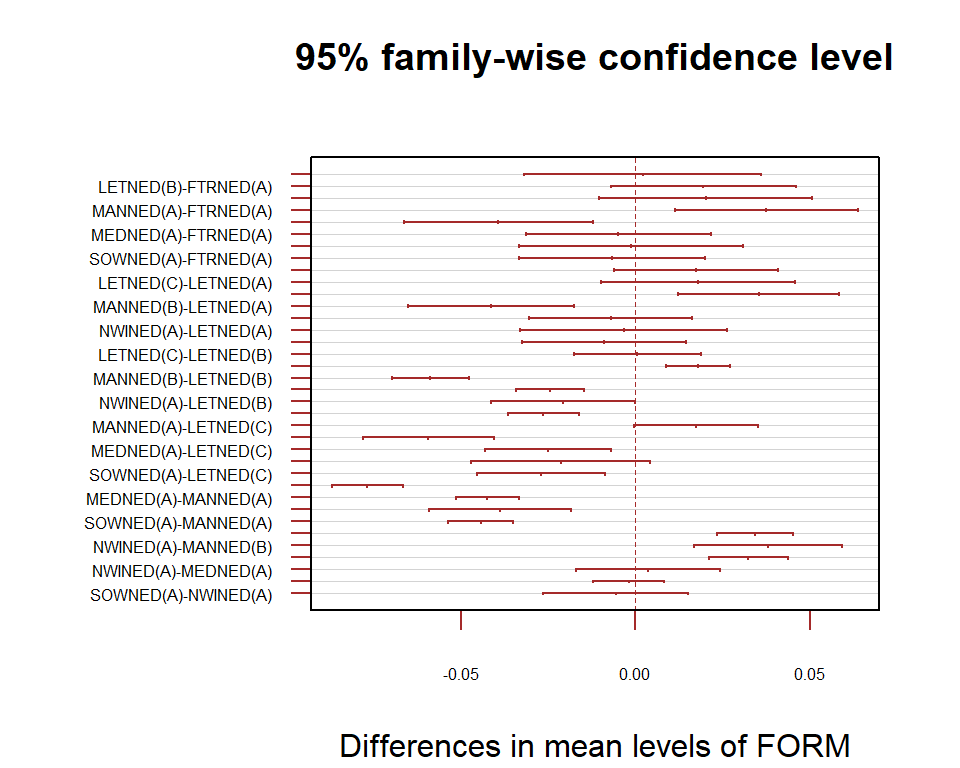

```r
par(mar = c(4, 8, 4, 2) + 0.1)
plot(posthoc_tukey, las = 1, col = "brown", cex.axis = 0.5)
```

The x-axis here represents difference in mean % score, so 0.05 represents a 5 point difference in a score of 100.

Let’s look only at the significant differences, arranged by difference in mean between groups.

```r
x <- as.data.frame(posthoc_tukey$FORM)

# Add a new column 'is_sig' based on 'p.adj' values
x$sig <- x$'p adj' <= 0.05

# Print the updated data frame

x <- x[order(x$diff), ]
y <- x[x$sig, ]
z <- arrange(y, diff)
z
```

```
##                            diff          lwr           upr        p adj  sig
## MANNED(B)-MANNED(A) -0.07663530 -0.086889783 -6.638081e-02 2.552442e-09 TRUE
## MANNED(B)-LETNED(C) -0.05925613 -0.078026624 -4.048563e-02 2.552531e-09 TRUE
## MANNED(B)-LETNED(B) -0.05864975 -0.069658823 -4.764068e-02 2.552442e-09 TRUE
## SOWNED(A)-MANNED(A) -0.04425045 -0.053654737 -3.484616e-02 2.552442e-09 TRUE
## MEDNED(A)-MANNED(A) -0.04235648 -0.051314460 -3.339849e-02 2.552442e-09 TRUE
## MANNED(B)-LETNED(A) -0.04130320 -0.065156835 -1.744956e-02 2.887317e-06 TRUE
## MANNED(B)-FTRNED(A) -0.03913939 -0.066061297 -1.221748e-02 2.269038e-04 TRUE
## NWINED(A)-MANNED(A) -0.03868337 -0.058938932 -1.842780e-02 1.213061e-07 TRUE
## SOWNED(A)-LETNED(C) -0.02687128 -0.045191149 -8.551405e-03 1.882115e-04 TRUE
## SOWNED(A)-LETNED(B) -0.02626490 -0.036486733 -1.604307e-02 2.552631e-09 TRUE
## MEDNED(A)-LETNED(C) -0.02497730 -0.043072126 -6.882483e-03 6.332731e-04 TRUE
## MEDNED(A)-LETNED(B) -0.02437093 -0.034183711 -1.455815e-02 2.553055e-09 TRUE
## NWINED(A)-LETNED(B) -0.02069782 -0.041345656 -4.998434e-05 4.889482e-02 TRUE
## MANNED(A)-LETNED(B)  0.01798555  0.008904245  2.706685e-02 3.338801e-08 TRUE
## SOWNED(A)-MANNED(B)  0.03238485  0.021107871  4.366183e-02 2.552514e-09 TRUE
## MEDNED(A)-MANNED(B)  0.03427882  0.023371252  4.518639e-02 2.552529e-09 TRUE
## MANNED(A)-LETNED(A)  0.03533210  0.012304587  5.835962e-02 6.916812e-05 TRUE
## MANNED(A)-FTRNED(A)  0.03749591  0.011303171  6.368865e-02 3.115577e-04 TRUE
## NWINED(A)-MANNED(B)  0.03795193  0.016761898  5.914197e-02 1.030619e-06 TRUE
```

Let’s have a look at the significant difference in means in a graphical form:

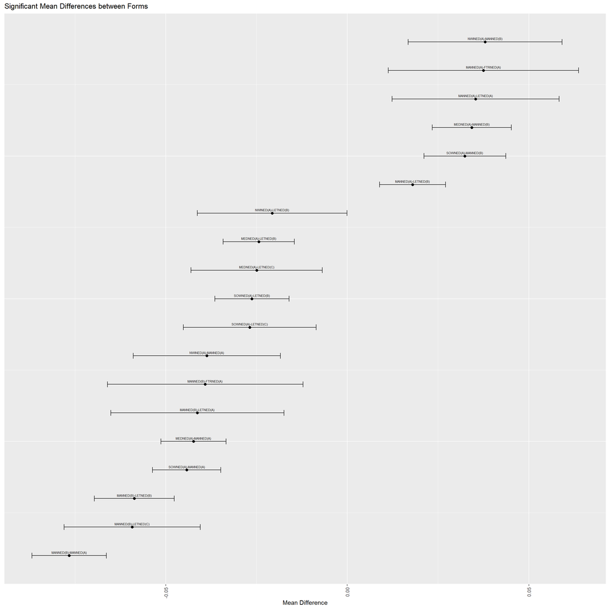

```r
z <- z %>%
  mutate(row_order = row_number())

# Sort the data frame based on the 'diff' column
z <- arrange(z, diff)

plot <- ggplot(z, aes(x = diff, y = row_order)) +
  geom_errorbarh(aes(xmin = lwr, xmax = upr), height = 0.2) +
  geom_point(size = 2) +
  geom_text(aes(label = rownames(z)), vjust = -.8,  size = 2) +  # Add row names as text
  labs(title = "Significant Mean Differences between Forms",
       x = "Mean Difference",
       y = "Row")


plot <- plot + theme(axis.text.x = element_text(angle = 90, vjust = 0.5, hjust = 1),
                     axis.title.y = element_blank(),
                     axis.text.y = element_blank(),
                     axis.ticks.y = element_blank())

# Display the plot
print(plot)
```

It appears as if there are some significant differences in means between groups, which largely fall between 2.5 points and 5 points on a 100 point test. The difference between the two MANNED forms, however, shows a difference in over 7 points, and these two forms show significant differences with many other forms as well.

As we had some earlier concerns about the use of the ANOVA as the data violates some of its assumptions, let’s explore a non-parametric alternative.

## 8.1 Kruskal-Wallis

The Kruskal-Wallis test is a non-parametric statistical test used to determine if there are any statistically significant differences between three or more independent groups. It is an extension of the Mann-Whitney U test, which is used to compare two independent groups. The Kruskal-Wallis test is suitable when the data do not meet the assumptions of parametric tests, such as the assumption of normality or equal variances.

The Kruskal-Wallis test is a hypothesis test that compares group medians, not means. If the test suggests significant differences between the groups, further post-hoc tests (e.g., Dunn’s test) can be conducted to identify which specific groups differ significantly from each other.

First, let’s inspect the medians.

```r
medians <- aggregate(SCORES ~ FORM, data = forms_scores2, FUN = median)
medians_ordered <- medians %>%
  arrange(desc(SCORES))


# Print the ordered medians
print("The median scores of all forms in descending order")
```

```
## [1] "The median scores of all forms in descending order"
```

```r
print(medians_ordered)
```

```
##        FORM    SCORES
## 1 MANNED(A) 0.8130081
## 2 LETNED(B) 0.7967480
## 3 LETNED(C) 0.7967480
## 4 FTRNED(A) 0.7804878
## 5 NWINED(A) 0.7786885
## 6 LETNED(A) 0.7763158
## 7 MEDNED(A) 0.7723577
## 8 SOWNED(A) 0.7723577
## 9 MANNED(B) 0.7398374
```

The differences are around 0.08 (8 points), and this spread and the figures match very closely to mean scores.

```r
# Perform the Kruskal-Wallis test
kruskal_result <- kruskal.test(SCORES ~ FORM, data = forms_scores2)
```

The Kruskal-Wallis test revealed a significant difference among the groups based on the scores (chi-squared = 579.33, df = 8, p < 0.001). For a post-hoc analysis, I used Dunn’s test.

```r
# Perform Dunn's test as a post-hoc test
dunn_result <- dunn.test(forms_scores2$SCORES, g = forms_scores2$FORM, method = "bonferroni")
```

```
##   Kruskal-Wallis rank sum test
##
## data: x and group
## Kruskal-Wallis chi-squared = 579.3299, df = 8, p-value = 0
##
##
##                            Comparison of x by group
##                                  (Bonferroni)
## Col Mean-|
## Row Mean |   FTRNED(A   LETNED(A   LETNED(B   LETNED(C   MANNED(A   MANNED(B
## ---------+------------------------------------------------------------------
## LETNED(A |   0.580661
##          |     1.0000
## LETNED(B |  -1.583865  -2.637984
##          |     1.0000     0.1501
## LETNED(C |  -1.555851  -2.410813  -0.306314
##          |     1.0000     0.2865     1.0000
## MANNED(A |  -3.639300  -4.994615  -5.875277  -2.698864
##          |    0.0049*    0.0000*    0.0000*     0.1252
## MANNED(B |   4.623365   4.392599   15.11825   9.163285   21.43384
##          |    0.0001*    0.0002*    0.0000*    0.0000*    0.0000*
## MEDNED(A |   1.196498   0.512882   7.502638   4.376017   14.17471  -8.509334
##          |     1.0000     1.0000    0.0000*    0.0002*    0.0000*    0.0000*
## NWINED(A |   0.694321   0.087672   3.111732   2.722663   5.806093  -4.822426
##          |     1.0000     1.0000     0.0335     0.1166    0.0000*    0.0000*
## SOWNED(A |   1.460017   0.815306   7.906478   4.715108   14.26730  -7.592390
##          |     1.0000     1.0000    0.0000*    0.0000*    0.0000*    0.0000*
## Col Mean-|
## Row Mean |   MEDNED(A   NWINED(A
## ---------+----------------------
## NWINED(A |  -0.455048
##          |     1.0000
## SOWNED(A |   0.711692   0.796855
##          |     1.0000     1.0000
##
## alpha = 0.05
## Reject Ho if p <= alpha/2
```

```r
# Display the post-hoc test results
#print(dunn_result)
```

## 8.2 Tukey vs Dunn sig pairs

Let’s compare the values for the Tukey (means) and the Dunn (median) tests.

```
##              comparisons   diff_median  sig
## 1  FTRNED(A) - MANNED(A)  4.920824e-03 TRUE
## 2  LETNED(A) - MANNED(A)  1.061154e-05 TRUE
## 3  LETNED(B) - MANNED(A)  7.598439e-08 TRUE
## 4  FTRNED(A) - MANNED(B)  6.796141e-05 TRUE
## 5  LETNED(A) - MANNED(B)  2.016057e-04 TRUE
## 6  LETNED(B) - MANNED(B)  2.209615e-50 TRUE
## 7  LETNED(C) - MANNED(B)  9.061326e-19 TRUE
## 8  MANNED(A) - MANNED(B) 1.162988e-100 TRUE
## 9  LETNED(B) - MEDNED(A)  1.125826e-12 TRUE
## 10 LETNED(C) - MEDNED(A)  2.175615e-04 TRUE
## 11 MANNED(A) - MEDNED(A)  2.364626e-44 TRUE
## 12 MANNED(B) - MEDNED(A)  3.148830e-16 TRUE
## 13 LETNED(B) - NWINED(A)  3.347876e-02 TRUE
## 14 MANNED(A) - NWINED(A)  1.151052e-07 TRUE
## 15 MANNED(B) - NWINED(A)  2.552799e-05 TRUE
## 16 LETNED(B) - SOWNED(A)  4.765888e-14 TRUE
## 17 LETNED(C) - SOWNED(A)  4.348471e-05 TRUE
## 18 MANNED(A) - SOWNED(A)  6.297103e-45 TRUE
## 19 MANNED(B) - SOWNED(A)  5.653038e-13 TRUE
```

```r
dunn_pairs <- dunn_summary_filtered$comparisons
tukey_pairs <- rownames(z)
dunn_pairs <- gsub(" ", "", dunn_pairs)
dunn_pairs <- sub("(.*)-(.*)", "\\2-\\1", dunn_pairs)
dunn_pairs <- sort(dunn_pairs)
tukey_pairs <- sort(tukey_pairs)
# Assuming you have vectors named dunn_pairs and tukey_pairs

# Compare elements and identify those present in dunn_pairs but not in tukey_pairs
in_dunn_not_in_tukey <- setdiff(dunn_pairs, tukey_pairs)

# Compare elements and identify those present in tukey_pairs but not in dunn_pairs
in_tukey_not_in_dunn <- setdiff(tukey_pairs, dunn_pairs)

# Print the results
cat("Length of dunn_pairs: ", length(dunn_pairs), "\n")
cat("Length of tukey_pairs: ", length(tukey_pairs), "\n")
cat("Elements in dunn_pairs but not in tukey_pairs:", in_dunn_not_in_tukey, "\n")
cat("Elements in tukey_pairs but not in dunn_pairs:", in_tukey_not_in_dunn, "\n")
```

```
## Length of dunn_pairs:  19
## Length of tukey_pairs:  19
## Elements in dunn_pairs but not in tukey_pairs:
## Elements in tukey_pairs but not in dunn_pairs:
```

The significant pairs are the same for both ANOVA/Tukey’s (means) and Kruskal-Wallis, Dunn’s (medians). I am comfortable assuming that these 19 pairs (and only these 19 pairs, out of 36 pairs total) are significantly different.

```r
#dunn_pairs
```

### 8.2.1 Differences between forms - summary

Because the two tests (ANOVA and Kruskal-Wallis) have such similar results, I feel comfortable accepting the Tukey Test results as indications of the difference in means. The extent to which this matters has to do with the fact that the test has some different items and is taken by different students. Some programs may have stricter and higher admissions requirements, and therefore their students may do better than those from another faculty with lower admittance criteria, or similar reasons. Fortunately, the test items are about 50/50 common (in all test forms for a particular year) and tailored (crafted to reflect context in the faculty). That means we can explore things on this level to see the differences in forms on common items only, and use this to investigate the effect of the tailored items. This in essence is test form equating, and will be later explored in a Rasch analysis.

# 9 Common Forms

All forms have some common items. Some forms have the same common items. Forms with the same common items can be equated to see what the effect of tailored items are later on.

## 9.1 Items / Form

First, let’s create a data frame (form_items) containing the ids of all items for each form. Inspection of the column names shows the first candidate from each of the 9 forms.

```
## [1] "FTRNED21221e1" "LETNED19201e1" "LETNED20211e1" "LETNED20212e1"
## [5] "MANNED20211e1" "MANNED22231e1" "MEDNED21221e1" "NWINED21221e1"
## [9] "SOWNED22231e1"
```

## 9.2 The 6 ‘Common’ Forms

Six forms use the same COMMON items. These are: FTRNED(A), LETNED(B), MANNED(B), MEDNED(A), NWINED(A), SOWNED(A).

Notes: NWINED(A) has that one removed dictee item 4. This should be removed for all forms when comparisons are made.

Notes: LETNED(B) uses a different item: Rn-Lees-Log-TekstVerband-02_ while the others use Rn-Lees-Log-TekstVerband-2. These two items are identical except that one distractor is different. We will use them as if they are the same, while recognizing that they are only nearly the same.

Form_items_overlap: the col names below show the six forms.

```r
forms_to_delete <- c(2,4,5)
form_items_overlap <- form_items[, -forms_to_delete]
colnames(form_items_overlap)
```

```
## [1] "FTRNED21221e1" "LETNED20211e1" "MANNED22231e1" "MEDNED21221e1"
## [5] "NWINED21221e1" "SOWNED22231e1"
```

## 9.3 New Column commontailored

It will be useful to isolate the types of items that are common and the type that are tailored. This process is somewhat complicated as the naming convention used for item IDs is not always regular. I use a system in which a string is searched for within an Item ID to classify it. This circumvents the problem that item IDs do not always follow the same format.

Common items: drogreden, signaalwoorden, tekstargument, tekstbegrip, tekstverband, woordbetekenis, samenvatting, dictee, interpunctie.

Tailored items: hotspot, juistofonjuist, kiesvorm, lezing, voorzetsels.

```r
search_terms_common <- c("drog", "signaal", "argument", "begrip", "verband", "betekenis", "samenvat", "dictee", "woordvorm", "interp")
search_terms_tailored <- c("hotspot", "juist", "kiesvorm", "lezing", "voorzet")
search_terms_all <- c("drog", "signaal", "argument", "begrip", "verband", "betekenis", "samenvat", "dictee", "woordvorm", "interp","hotspot", "juist", "kiesvorm", "lezing", "voorzet")
```

```r
# Create a new column with NA values
nedallplus_no_outliers_2 <- nedallplus_no_outliers
nedallplus_no_outliers_2$commontailored <- NA
# Search for common terms and assign "common" to the new column where matched
for (term in search_terms_common) {
  match_rows <- grepl(term, rownames(nedallplus_no_outliers_2), ignore.case = TRUE)
  nedallplus_no_outliers_2$commontailored[match_rows] <- "common"
}
# Search for tailored terms and assign "tailored" to the new column where matched
for (term in search_terms_tailored) {
  match_rows <- grepl(term, rownames(nedallplus_no_outliers_2), ignore.case = TRUE)
  nedallplus_no_outliers_2$commontailored[match_rows] <- "tailored"
}
last_col_index <- ncol(nedallplus_no_outliers_2)
# Move the last column to the first position
nedallplus_no_outliers_2 <- cbind(nedallplus_no_outliers_2[, last_col_index], nedallplus_no_outliers_2[, -last_col_index])
colnames(nedallplus_no_outliers_2)[1] <- "commontailored"
```

A new column in the dataset contains common or tailored for each item.

## 9.4 Comparing Commmon Means

```r
common_items <- nedallplus_no_outliers_2[nedallplus_no_outliers_2$commontailored %in% c("common", NA), ]
# delete the problematic dictee 4
common_items <- common_items[rownames(common_items) != "Rn-Schr-Sp-Dictee-04", ]

common_items <- common_items[,-1]
rownames <- rownames(common_items)
# Subset the data to include rows from row 8 and columns from column 2 onward
selected_data <- common_items[8:nrow(common_items), 1:ncol(common_items)]
# Convert each column to numeric using sapply
selected_data <- sapply(selected_data, as.numeric)
# Calculate the column sums for the selected data
column_sums <- colSums(selected_data, na.rm = TRUE)
column_counts <- colSums(!is.na(selected_data))
common_perc_row <- column_sums/column_counts
common_items_2 <- rbind(common_perc_row, common_items)
rownames(common_items_2) <- c("COMMON_PERC", rownames)
```

The means of the common items of these six forms shows that for these identical forms, there remains some difference in means, though not large.

LETNED(A) stands out. An inspection of the data set shows that for one 6-point section Rn-Schr-Sp-WoordVorm-01, there were no points for these test takers, showing that this item was either not given, or removed, or something else has gone wrong in the data. The values in the table should not be seen as a correct representation of performance.

```r
common_items_3 <- as.data.frame(t(common_items_2))
common_items_3$COMMON_PERC <- as.numeric(common_items_3$COMMON_PERC)
statistics_df <- common_items_3 %>%
  group_by(FORM) %>%
  summarise(N = n(),
            mean = mean(COMMON_PERC),
            median = median(COMMON_PERC),
            SD = sd(COMMON_PERC, na.rm=TRUE))

# Step 2: Display statistics in table format
print(statistics_df)
```

```
## # A tibble: 9 × 5
##   FORM          N  mean median     SD
##   <chr>     <int> <dbl>  <dbl>  <dbl>
## 1 FTRNED(A)    67 0.808  0.829 0.100
## 2 LETNED(A)    88 0.716  0.721 0.0429
## 3 LETNED(B)   888 0.833  0.843 0.0707
## 4 LETNED(C)   156 0.835  0.845 0.0728
## 5 MANNED(A)  1317 0.828  0.831 0.0727
## 6 MANNED(B)   608 0.772  0.786 0.0752
## 7 MEDNED(A)   930 0.790  0.8   0.0741
## 8 NWINED(A)   116 0.803  0.814 0.0743
## 9 SOWNED(A)   792 0.797  0.8   0.0696
```

A violin chart shows the distributions of performance on these forms when only common items are graded.

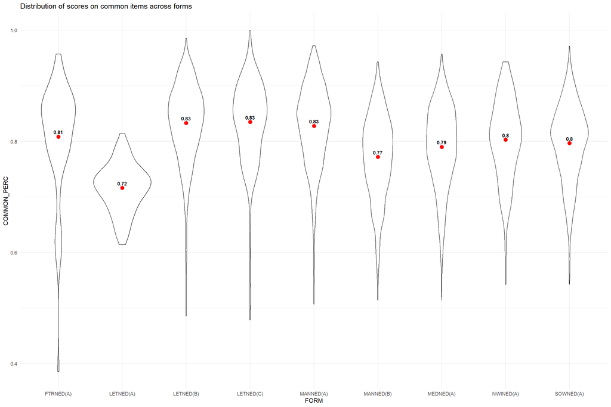

```r
ggplot(common_items_3, aes(x = FORM, y = COMMON_PERC)) +
  geom_violin() +
  geom_point(data = statistics_df, aes(y = mean), size = 3, color = "red") +
  geom_text(data = statistics_df, aes(y = mean, label = round(mean, 2)), vjust = -0.7, size = 3, fontface = "bold") +

  labs(x = "FORM", y = "COMMON_PERC", title = "Distribution of scores on common items across forms") +
  theme_minimal()
```

Remember that not all these forms contain the same common items. Let’s restrict the data to those forms that share common items.

The descriptive statistics for these six forms (common only), ordered by mean score:

```r
matched_form_common_items$COMMON_PERC <- as.numeric(matched_form_common_items$COMMON_PERC)
statistics_df <- matched_form_common_items %>%
  group_by(FORM) %>%
  summarise(N = n(),
            mean = mean(COMMON_PERC),
            median = median(COMMON_PERC),
            SD = sd(COMMON_PERC, na.rm=TRUE)) %>%
  arrange(mean)

# Step 2: Display statistics in table format
print(statistics_df)
```

```
## # A tibble: 6 × 5
##   FORM          N  mean median     SD
##   <chr>     <int> <dbl>  <dbl>  <dbl>
## 1 MANNED(B)   608 0.772  0.786 0.0752
## 2 MEDNED(A)   930 0.790  0.8   0.0741
## 3 SOWNED(A)   792 0.797  0.8   0.0696
## 4 NWINED(A)   116 0.803  0.814 0.0743
## 5 FTRNED(A)    67 0.808  0.829 0.100
## 6 LETNED(B)   888 0.833  0.843 0.0707
```

The violin chart

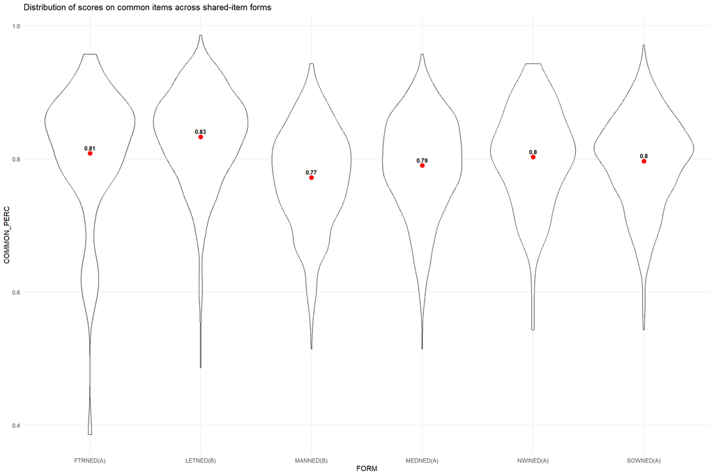

```r
ggplot(matched_form_common_items, aes(x = FORM, y = COMMON_PERC)) +
  geom_violin() +
  geom_point(data = statistics_df, aes(y = mean), size = 3, color = "red") +
  geom_text(data = statistics_df, aes(y = mean, label = round(mean, 2)), vjust = -0.7, size = 3, fontface = "bold") +

  labs(x = "FORM", y = "COMMON_PERC", title = "Distribution of scores on common items across shared-item forms") +
  theme_minimal()
```

Some of the violins are truncated. To double check the data, let’s look at this data in another way - individual histograms of the scores.

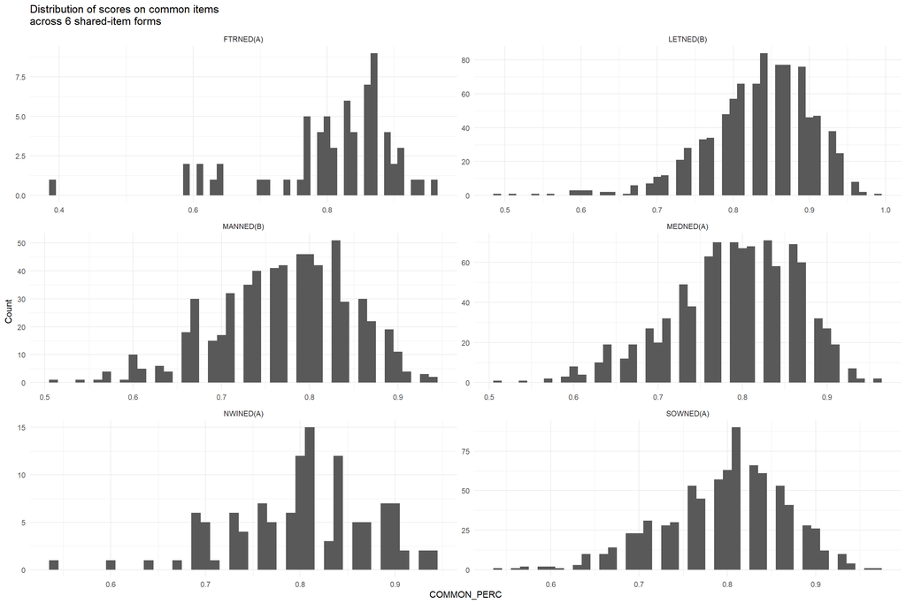

```r
ggplot(matched_form_common_items, aes(x = COMMON_PERC)) +
  geom_histogram(binwidth = 0.01) +
  facet_wrap(~ FORM, ncol = 2, scales = "free") +
  labs(x = "COMMON_PERC", y = "Count", title = "Distribution of scores on common items\nacross 6 shared-item forms") +
  theme_minimal()
```

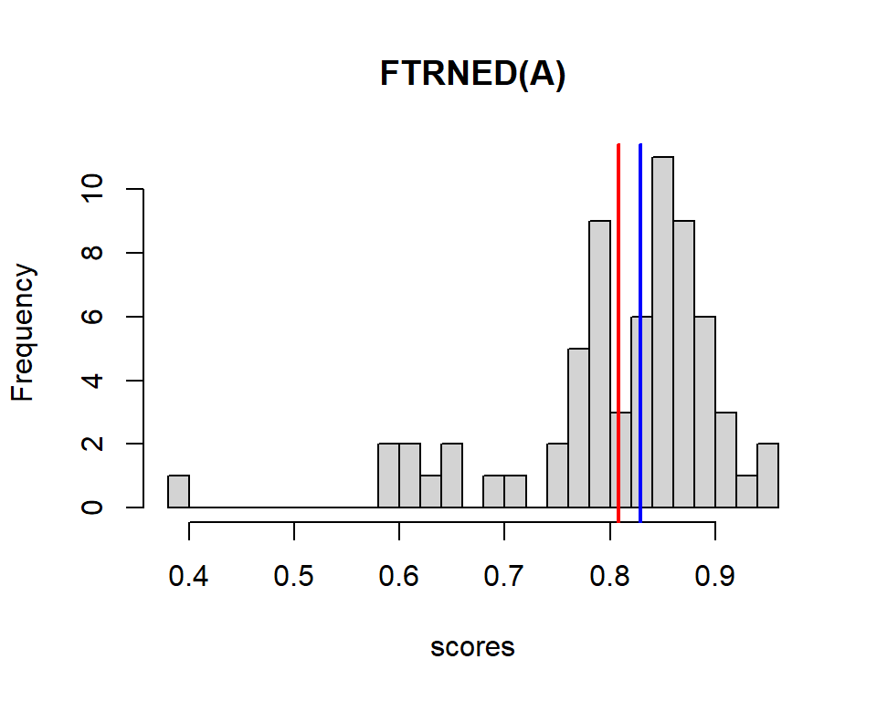

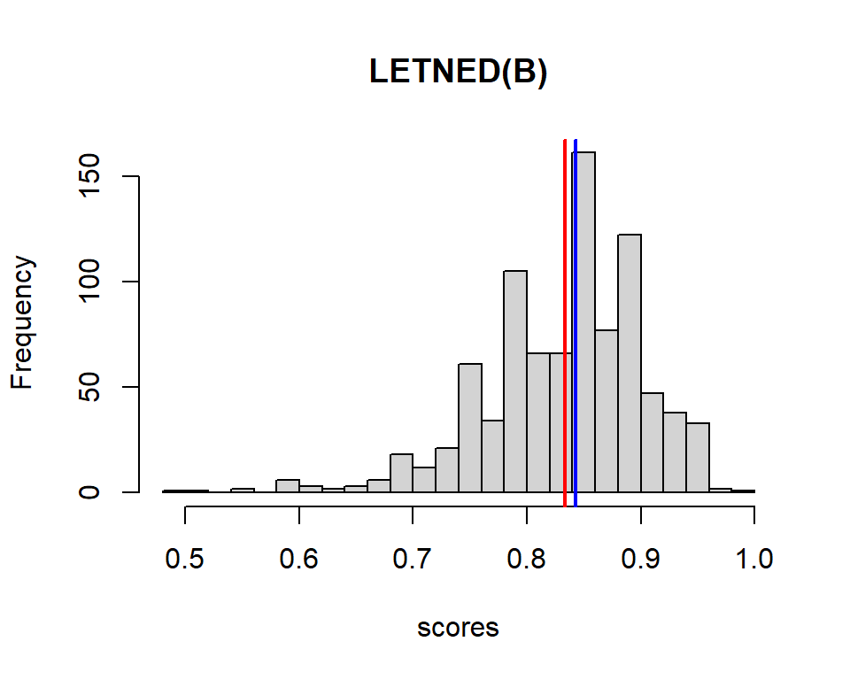

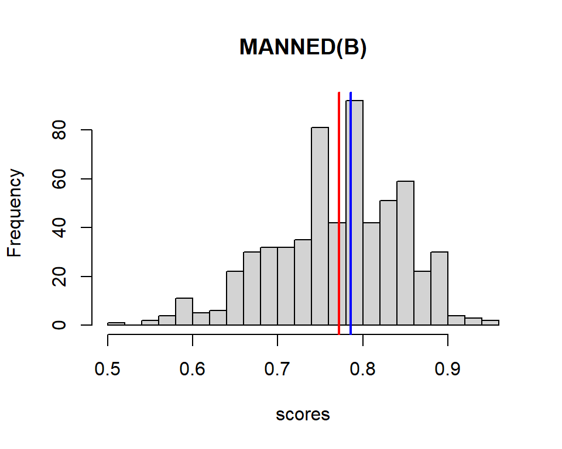

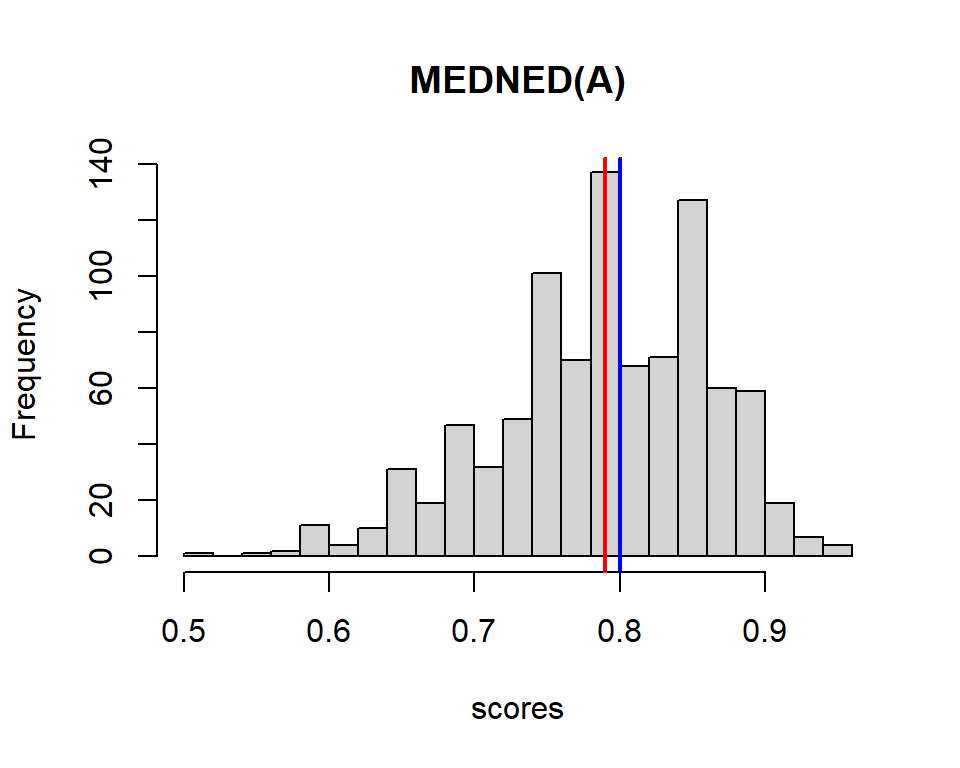

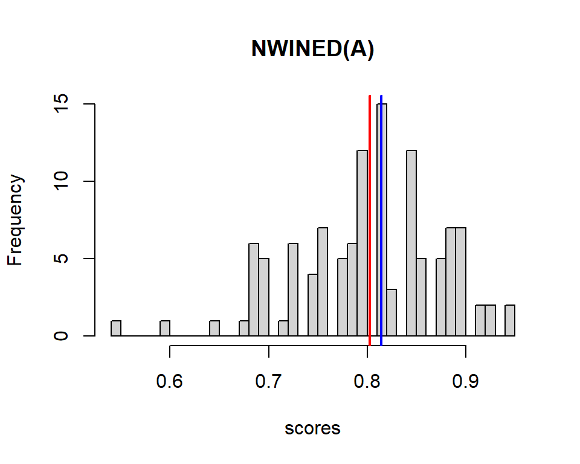

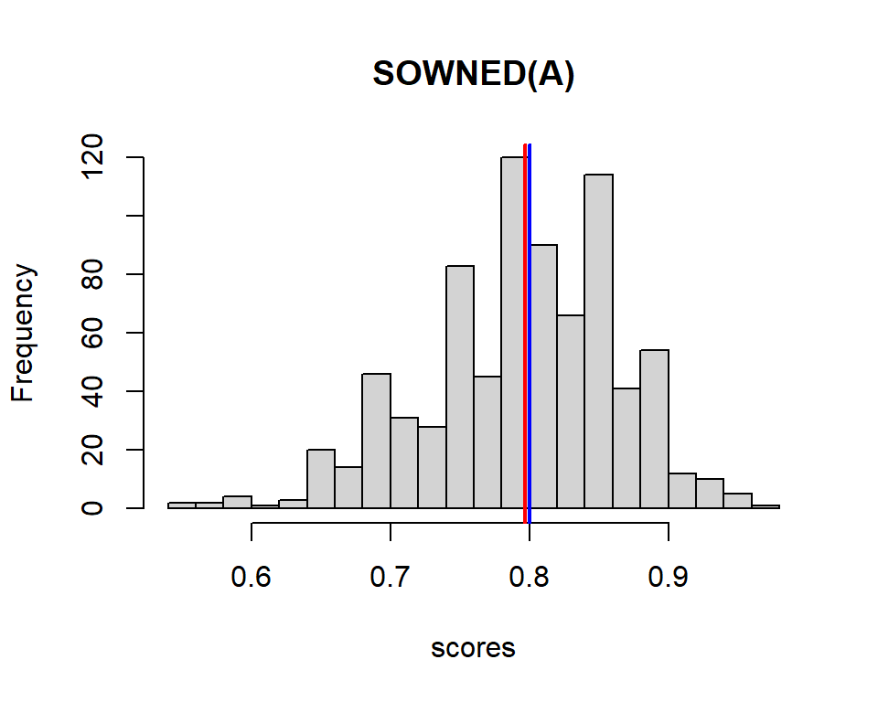

```r
results<- c()
for (group in unique(matched_form_common_items$FORM)) {
  scores <- matched_form_common_items$COMMON_PERC[matched_form_common_items$FORM == group]  # Subset scores for the current group
  skew <- skewness(scores)
  kurt <- kurtosis(scores)
  results<- c(results, group, length(scores), skew, kurt)
  hist(scores, main = group, breaks=(30))
  # Calculate the mean and median
  mean_score <- mean(scores)
  median_score <- median(scores)

  # Add the mean line
  abline(v = mean_score, col = "red", lwd = 2)

  # Add the median line
  abline(v = median_score, col = "blue", lwd = 2)
}
```

```r
results_table <- matrix(results, ncol=4, byrow=TRUE)
colnames(results_table) <- c("Form", "N", "Skewness", "Kurtosis")
results_table
```

```
##      Form        N     Skewness             Kurtosis
## [1,] "FTRNED(A)" "67"  "-1.68903102240263"  "6.6982951471635"
## [2,] "LETNED(B)" "888" "-0.943386352636011" "4.76086202879535"
## [3,] "MANNED(B)" "608" "-0.427804695873563" "2.93991260279425"
## [4,] "MEDNED(A)" "930" "-0.523415776490812" "3.02196543257121"
## [5,] "NWINED(A)" "116" "-0.560520757265236" "3.44058074126816"
## [6,] "SOWNED(A)" "792" "-0.505479308152976" "3.21412879836775"
```

```r
kruskal_result <- kruskal.test(COMMON_PERC ~ FORM, data = matched_form_common_items)
print(kruskal_result)
```

```
##
##  Kruskal-Wallis rank sum test
##
## data:  COMMON_PERC by FORM
## Kruskal-Wallis chi-squared = 295.39, df = 5, p-value < 2.2e-16
```

```r
# Perform Dunn's test as a post-hoc test
dunn_result <- dunn.test(matched_form_common_items$COMMON_PERC, g = matched_form_common_items$FORM, method = "bonferroni")
```

```
##   Kruskal-Wallis rank sum test
##
## data: x and group
## Kruskal-Wallis chi-squared = 295.3858, df = 5, p-value = 0
##
##
##                            Comparison of x by group
##                                  (Bonferroni)
## Col Mean-|
## Row Mean |   FTRNED(A   LETNED(B   MANNED(B   MEDNED(A   NWINED(A
## ---------+-------------------------------------------------------
## LETNED(B |  -1.637488
##          |     0.7615
## MANNED(B |   4.848130   15.79696
##          |    0.0000*    0.0000*
## MEDNED(A |   3.047339   12.63730  -4.575060
##          |    0.0173*    0.0000*    0.0000*
## NWINED(A |   1.445357   4.347862  -3.970542  -1.662294
##          |     1.0000    0.0001*    0.0005*     0.7234
## SOWNED(A |   2.469885   10.67439  -5.746047  -1.472965   0.930066
##          |     0.1014    0.0000*    0.0000*     1.0000     1.0000
##
## alpha = 0.05
## Reject Ho if p <= alpha/2
```

```r
comparisons <- as.vector(dunn_result$comparisons)
p <- as.vector(dunn_result$P)
padj <- as.vector(dunn_result$P.adjusted)

df <- data.frame(comparisons, p, padj)
df$sig <- ifelse(df$padj <= 0.05, "sig at 0.05", "non-sig")
filtered_df <- subset(df, sig == "sig at 0.05")
significant_comparisons_common_six <- as.vector(filtered_df$comparisons)
cat("The significantly different pairings identified in Dunn's test are: \n")
```

```
## The significantly different pairings identified in Dunn's test are:
```

```r
print(significant_comparisons_common_six)
```

```
## [1] "FTRNED(A) - MANNED(B)" "LETNED(B) - MANNED(B)" "FTRNED(A) - MEDNED(A)"
## [4] "LETNED(B) - MEDNED(A)" "MANNED(B) - MEDNED(A)" "LETNED(B) - NWINED(A)"
## [7] "MANNED(B) - NWINED(A)" "LETNED(B) - SOWNED(A)" "MANNED(B) - SOWNED(A)"
```

# 10 More detail to dataset

Column commonscore added to the data set

```r
nedallplus_no_outliers_3 <- nedallplus_no_outliers_2
nedallplus_no_outliers_3$item <- rownames(nedallplus_no_outliers_3)

# Convert rows 1 to 7 to NA
# Move the 'item' column to the first position
nedallplus_no_outliers_3$task <- NA

z <- search_terms_all
x <- as.vector(nedallplus_no_outliers_3$item)
y <- c()
```

```r
# Initialize an empty vector y
y <- character(length(x))

# Perform the search and populate vector y
for (i in seq_along(x)) {
  # Convert the element in x to lowercase for case-insensitive search
  x_lower <- tolower(x[i])

  # Check each term in z against the element in x
  for (term in z) {
    term_lower <- tolower(term)

    # If a match is found, add the term to y and break out of the loop
    if (grepl(term_lower, x_lower)) {
      y[i] <- term
      break
    }
  }
}

nedallplus_no_outliers_3$task <- y
```

```r
x <- nedallplus_no_outliers_3
x$item[1:7] <- ""
x <- x[x$commontailored == 'common', ]
x <- x[,-c(1, 4965, 4964)]
x <- apply(x, 2, function(col) as.numeric(as.character(col)))
y <- nedallplus_no_outliers_3
y$item[1:7] <- ""
y <- y[y$commontailored == 'tailored', ]
y <- y[,-c(1, 4965, 4964)]
y <- apply(y, 2, function(col) as.numeric(as.character(col)))
```

```r
x_col <- colSums(x, na.rm=TRUE)
y_col <- colSums(y, na.rm=TRUE)
z_col <- x_col + y_col

hspot <- as.numeric(as.vector(nedallplus_no_outliers_3["HSPOT_MAX", ]))
hspot <- hspot[-c(1, 4965, 4964)]
hspot[hspot == 8] <- 7# necessary for addition as hs has 1 poitn counted already


x_count <- colSums(!is.na(x))
y_count <- colSums(!is.na(y)) +hspot
z_count <- x_count + y_count

x_perc <- x_col/x_count
y_perc <- y_col/y_count
z_perc <- z_col/z_count

form <- unlist(as.vector(nedallplus_no_outliers_3["FORM", ]))
form <- form[-c(1, 4965, 4964)]

abc <- data.frame(form, x_perc, y_perc, z_perc)
```

```r
abc_long <- abc %>%
  gather(section, percentage, x_perc:z_perc)
```

These violin charts show the scores on common, tailored and all items across forms:

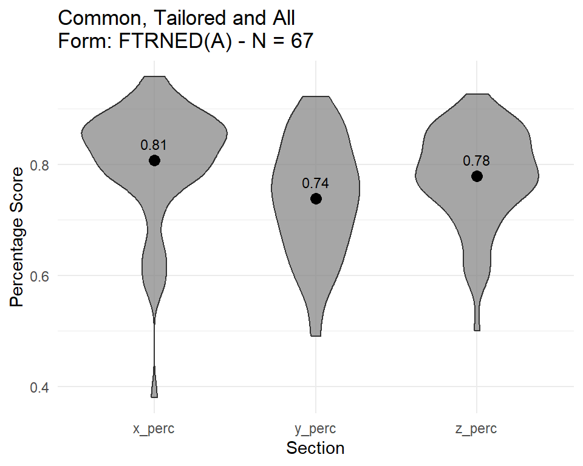

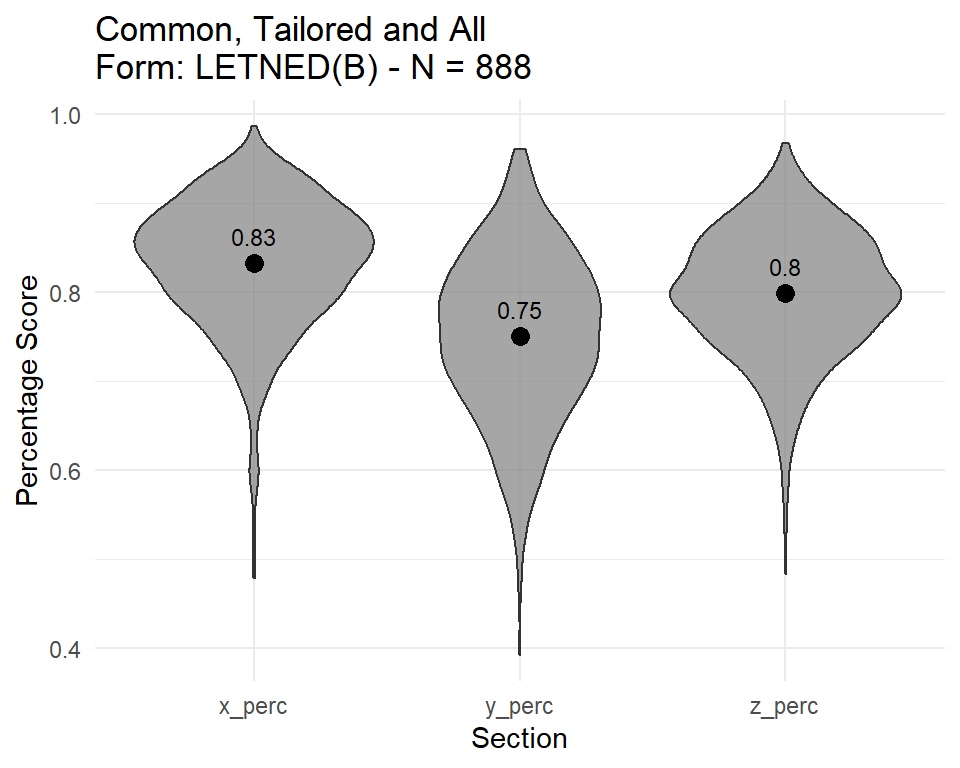

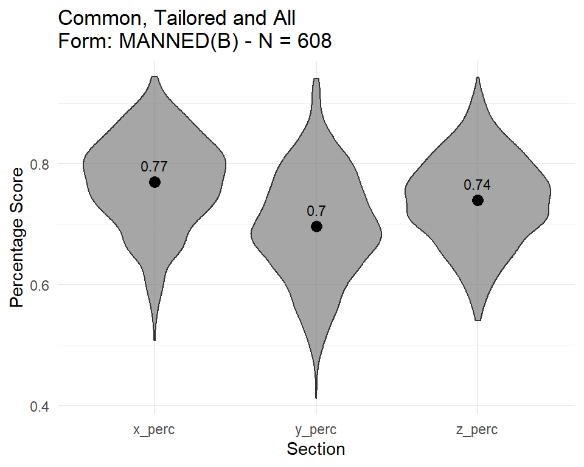

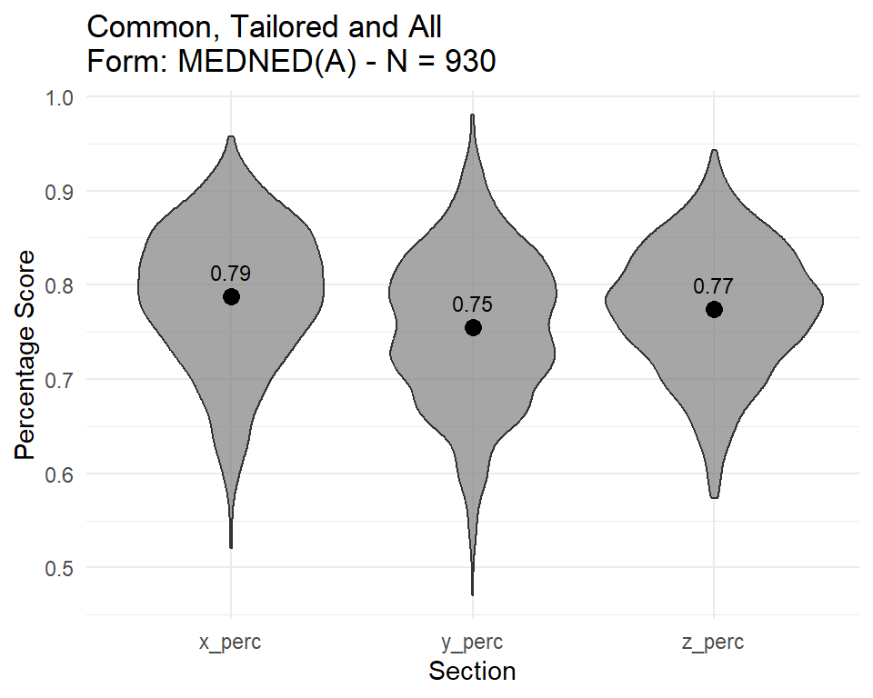

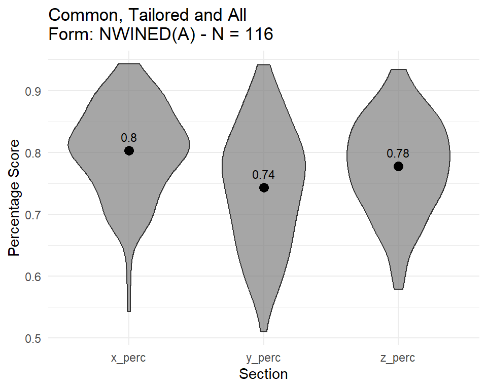

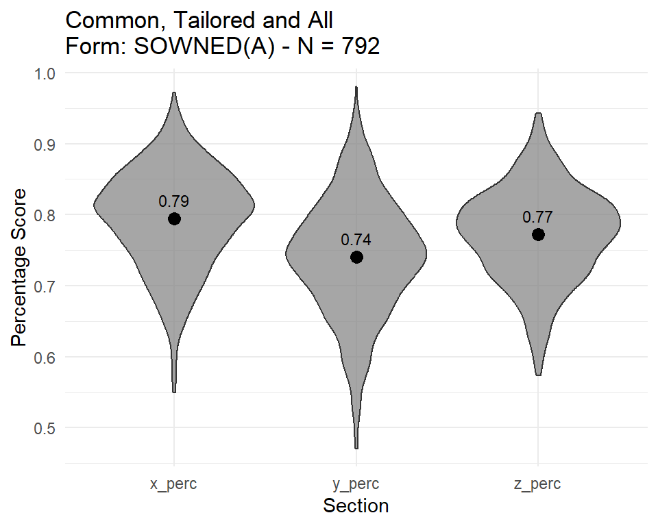

```r
# Get unique values of 'form'
unique_forms <- unique(abc_long$form)

# Initialize a list to store the plots
plot_list <- list()

# Loop through each unique value of 'form' and create the violin plot with 'section' as facet
for (form_val in unique_forms) {
  # Check if the current 'form_val' is in 'form_items_unique'
  if (form_val %in% form_items_unique) {
    # Filter the data for the current 'form' value
    data_subset <- abc_long[abc_long$form == form_val, ]

    # Calculate the mean for each section
    mean_values <- data_subset %>%
      group_by(section) %>%
      summarize(mean_perc = mean(percentage))

    # Get the N count for the current 'form'
    n_count <- nrow(data_subset)

    # Create the violin plot for this 'form' with 'section' as facet, and add mean dots and labels
    p <- ggplot(data_subset, aes(x = section, y = percentage, fill = section)) +
      geom_violin(alpha = 0.7) +
      geom_point(data = mean_values, aes(x = section, y = mean_perc), color = "black", size = 3) +
      geom_text(data = mean_values, aes(x = section, y = mean_perc, label = round(mean_perc, 2)),
                vjust = -1, size = 3, color = "black", show.legend = TRUE) +
      labs(title = paste("Common, Tailored and All\nForm:", form_val, "- N =", (n_count)/3),
           x = "Section",
           y = "Percentage Score") +
      scale_fill_manual(values = c("Common" = "blue", "Tailored" = "green", "Total" = "red"),
                        labels = c("Common", "Tailored", "Total")) +  # Labels for the legend
      theme_minimal()

    # Add the plot to the list
    plot_list[[as.character(form_val)]] <- p
  }
}

# Print the plots
for (i in seq_along(plot_list)) {
  print(plot_list[[i]])
}
```

```r
knitr::knit_exit()
```